# Final Project Technical Analysis

Team 6

2022-05-01

# Instructions

Technical analysis (R code), 25%. First attempt due on May 1 Sunday, the same time as as your team’s video presentation. Provide an R-markdown, or R script file, which shows the R-code and brief explanations as well as the rationale of the EDA and models you used. This submission, together with your final document (in part VI), will determine your team’s grade. This document shows a technical person the math/stat/codes that you used in your analysis. It should include:

- Codes of any models that you built
- Graph and chart outputs with your R codes
- [When applicable] Codes of any statistical tests you used
- Model evaluation(s) and comparison

# Topic Proposal

The results of our midterm project indicated that there was a relationship between income inequality and mental health, which varied geographically across regions of the U.S. In this next stage, we intend to use statistical models to better understand the strength of the relationship.

We plan to build a linear regression model that assesses the strength of this relationship. Our independent variable for measuring income inequality is the “ratio of household income at the 80th percentile to income at the 20th percentile.” We have two alternative measures of mental health that can be used as dependent variables: the rate of frequent mental distress and the average number of poor mental health days reported in the past 30 days. We also plan to include additional variables that are expected to affect mental health, including median household income, the percentage of households with severe housing problems, the unemployment rate, the child poverty rate, and county-level demographic information. Additionally, regression tree and random forest models will be used to determine variable importance and better predict the prevalence of mental health issues.

This discussion provokes the following SMART questions:

- Is the relationship between mental health and income inequality across U.S. counties robust when including other economic variables?
- Does the relationship differ across regions of the U.S.?
- Does the relationship depend on the measure used for mental health?

# Description of the Dataset

The primary dataset used for this project is a combination of annual datasets called the County Health Rankings and Roadmaps National Data and was obtained the Robert Wood Johnson Foundation (RWJF). The County Health Rankings and Roadmaps National Data consists of county-level socioeconomic and public health data. The reports published from 2016 to 2021 provided the most complete data for all the variables of interest. The annual datasets before 2016 were incomplete or did not have variables that exactly corresponded to variables in 2016 to 2021. In general, the years in the datasets reflect the year the report was released by RWJF, but the underlying source data are from a one or two calendar years earlier.

For the exploratory data analysis, the data was also separated into four regions defined by the [U.S. Census Bureau](https://www2.census.gov/geo/pdfs/maps-data/maps/reference/us_regdiv.pdf).

The variables in the data set are:

- `region`: name of the US Census Bureau region (name)
- `division`: name of the US Census Bureau division (contained with a census region)
- `state`: two letter state abbreviation
- `statecode`: FIPS state code
- `countycode`: FIPS county code
- `fipscode`: 5-digit FIPS Code (county-level); combines `statecode` and `countycode`
- `county`: county name
- `year`: report release year from [County Health Rankings](https://www.countyhealthrankings.org/); range of 2016-2021
- `county_ranked`: Indicates whether or not the county was ranked; 0=unranked, 1=ranked, or NA for aggregated national or state-level data
- `mental_health_days`: Average number of mentally unhealthy days reported in past 30 days (age-adjusted)
- `mental_distress_rate`: Percentage of adults reporting 14 or more days of poor mental health per month
- `inequality`: Ratio of household income at the 80th percentile to income at the 20th percentile (Income inequality)
- `median_inc`: The income where half of households in a county earn more and half of households earn less
- `hs_grad`: Percentage of adults ages 25 and over with a high school diploma or equivalent
- `college`: Percentage of adults ages 25-44 with some post-secondary education
- `unempl`: Percentage of population ages 16 and older unemployed but seeking work
- `child_poverty`: Percentage of people under age 18 in poverty
- `single_parent`: Percentage of children that live in a household headed by single parent
- `severe_housing`: Percentage of households with severe housing problems
- `food_index`: Index of factors that contribute to a healthy food environment, from 0 (worst) to 10 (best)
- `mh_providers`: rate of providers to 100,000 population
- `pop_provider_ratio`: ratio of population to mental health providers (i.e., population served per provider)
- `pop`: census population estimate
- `pct_below18`: percent of population younger than 18
- `pct_black`: percent of population that are African-American or non-Hispanic Black
- `pct_native_am`: percent of population that are Native American or Alaska Natives
- `pct_asian`: percent of population that are Asian
- `pct_pacific`: percent of population that are Native Hawaiian or Other Pacific Islander
- `pct_hispanic`: percent of population that are Hispanic
- `pct_white`: percent of population that are non-Hispanic white or Caucasian
- `pct_female`: percent of population that are female
- `pct_rural`: percent of population that live in rural areas

```r
# look at county_ranked var; not all counties are ranked; also some aggregated data per state and country exist in the observations
# =1 means they are ranked, =0 means unranked, and =NA is for state/national data
#print(summary(dframe$county_ranked))

# subset of dataframe including only ranked counties
ranked <- dframe %>% subset(county_ranked==1)

# subset of dataframe including only ranked counties
unranked <- dframe %>% subset(county_ranked==0)

# subset of dataframe including only aggregated data
aggregated <- dframe %>% subset(is.na(county_ranked))

# duplicate column and rename level labels for easier reading
ranked$region_abb <- ranked$region
levels(ranked$region_abb) <- c("",
                              "MW",  # re-level factor labels
                              "NE",
                              "S",
                              "W")

# subset ranked data by region
ranked_MW <- ranked %>% subset(region=="Midwest")
ranked_NE <- ranked %>% subset(region=="Northeast")
ranked_SO <- ranked %>% subset(region=="South")
ranked_WE <- ranked %>% subset(region=="West")

# subset ranked data into annual datasets
ranked16 <- ranked %>% subset(year==2016)
ranked17 <- ranked %>% subset(year==2017)
ranked18 <- ranked %>% subset(year==2018)
ranked19 <- ranked %>% subset(year==2019)
ranked20 <- ranked %>% subset(year==2020)
ranked21 <- ranked %>% subset(year==2021)

# sort dataframe
ranked <- ranked[order(ranked$year, ranked$region, ranked$division, ranked$statecode, ranked$countycode), ]
```

Our data are identified at the county-year level. Our data set contains 19164 observations and 32 variables, although 319 of these observations are for aggregated data at the national or state level. In addition, 375 observations are for counties that are unranked by [RWJF](https://www.countyhealthrankings.org/explore-health-rankings/faq-page), suggesting that the data for these counties is less reliable. In total, we have 18470 observations in the ranked data, combined across 6 annual reports (2016–2021). Each annual data set has between 3071 and 3084 observations, indicating that the number of ranked counties is consistent over time.

# Exploratory Data Analysis

## Descriptive Statistics

```r
#Summary Statistics of all Variables in dataset
# use ranked instead
table1<-describeBy(ranked, type = 1) ## type of kurtosis and skewness to calculate
table1 %>%
  kbl(caption="Summary Statistics for Master Dataset",
       format= "html", col.names = c("Var Num.","Count","Mean","Std. Dev.","Median", "Trimmed Mean", "Mad", "Minimum", "Maximum","Range", "Skewness", "Kurtosis", "S.E."),
      align="r") %>%
   kable_classic_2(full_width = F, html_font = "helvetica")
```

Summary Statistics for Master Dataset

|  | Var Num. | Count | Mean | Std. Dev. | Median | Trimmed Mean | Mad | Minimum | Maximum | Range | Skewness | Kurtosis | S.E. |
| --- | --- | --- | --- | --- | --- | --- | --- | --- | --- | --- | --- | --- | --- |
| region* | 1 | 18470 | 3.40e+00 | 1.09e+00 | 4.00e+00 | 3.37e+00 | 1.48e+00 | 2.000 | 5.00e+00 | 3.00e+00 | -0.198 | -1.396 | 0.008 |
| division* | 2 | 18470 | 6.50e+00 | 2.88e+00 | 8.00e+00 | 6.63e+00 | 2.96e+00 | 2.000 | 1.00e+01 | 8.00e+00 | -0.379 | -1.413 | 0.021 |
| state* | 3 | 18470 | 2.70e+01 | 1.42e+01 | 2.60e+01 | 2.73e+01 | 1.78e+01 | 1.000 | 5.10e+01 | 5.00e+01 | -0.028 | -1.205 | 0.105 |
| statecode* | 4 | 18470 | 2.82e+01 | 1.43e+01 | 2.70e+01 | 2.85e+01 | 1.78e+01 | 2.000 | 5.20e+01 | 5.00e+01 | -0.049 | -1.214 | 0.105 |
| countycode* | 5 | 18470 | 6.55e+01 | 5.82e+01 | 5.30e+01 | 5.61e+01 | 4.45e+01 | 2.000 | 3.29e+02 | 3.27e+02 | 1.949 | 4.759 | 0.428 |
| fipscode* | 6 | 18469 | 1.60e+03 | 9.23e+02 | 1.59e+03 | 1.60e+03 | 1.18e+03 | 3.000 | 3.20e+03 | 3.20e+03 | 0.010 | -1.204 | 6.793 |
| county* | 7 | 18470 | 9.43e+02 | 5.31e+02 | 9.45e+02 | 9.40e+02 | 6.61e+02 | 1.000 | 1.89e+03 | 1.89e+03 | 0.046 | -1.123 | 3.908 |
| year* | 8 | 18470 | 3.50e+00 | 1.71e+00 | 4.00e+00 | 3.50e+00 | 1.48e+00 | 1.000 | 6.00e+00 | 5.00e+00 | -0.002 | -1.268 | 0.013 |
| county_ranked* | 9 | 18470 | 2.00e+00 | 0.00e+00 | 2.00e+00 | 2.00e+00 | 0.00e+00 | 2.000 | 2.00e+00 | 0.00e+00 | NaN | NaN | 0.000 |
| mental_health_days | 10 | 18469 | 4.04e+00 | 6.92e-01 | 4.02e+00 | 4.03e+00 | 7.06e-01 | 2.100 | 7.29e+00 | 5.19e+00 | 0.223 | -0.112 | 0.005 |
| mental_distress_rate | 11 | 18469 | 1.26e-01 | 2.40e-02 | 1.24e-01 | 1.25e-01 | 2.40e-02 | 0.066 | 2.47e-01 | 1.81e-01 | 0.532 | 0.302 | 0.000 |
| inequality | 12 | 18465 | 4.52e+00 | 7.33e-01 | 4.41e+00 | 4.45e+00 | 6.28e-01 | 2.543 | 1.20e+01 | 9.43e+00 | 1.254 | 3.433 | 0.005 |
| median_inc | 13 | 18469 | 5.08e+04 | 1.36e+04 | 4.87e+04 | 4.93e+04 | 1.10e+04 | 21658.000 | 1.52e+05 | 1.30e+05 | 1.424 | 3.681 | 99.952 |
| hs_grad | 14 | 16563 | 8.70e-01 | 7.90e-02 | 8.83e-01 | 8.78e-01 | 6.70e-02 | 0.025 | 1.00e+00 | 9.75e-01 | -1.593 | 6.583 | 0.001 |
| college | 15 | 18469 | 5.71e-01 | 1.16e-01 | 5.72e-01 | 5.72e-01 | 1.22e-01 | 0.152 | 9.11e-01 | 7.59e-01 | -0.088 | -0.263 | 0.001 |
| unempl | 16 | 18469 | 5.00e-02 | 2.00e-02 | 4.60e-02 | 4.80e-02 | 1.70e-02 | 0.012 | 2.40e-01 | 2.28e-01 | 1.690 | 6.492 | 0.000 |
| child_poverty | 17 | 18469 | 2.21e-01 | 9.10e-02 | 2.09e-01 | 2.14e-01 | 9.00e-02 | 0.024 | 7.47e-01 | 7.23e-01 | 0.695 | 0.537 | 0.001 |
| single_parent | 18 | 18469 | 3.14e-01 | 1.06e-01 | 3.06e-01 | 3.08e-01 | 9.60e-02 | 0.000 | 8.72e-01 | 8.72e-01 | 0.696 | 1.251 | 0.001 |
| severe_housing | 19 | 18470 | 1.42e-01 | 4.70e-02 | 1.37e-01 | 1.39e-01 | 3.70e-02 | 0.022 | 7.13e-01 | 6.91e-01 | 2.086 | 14.166 | 0.000 |
| food_index | 20 | 18394 | 7.32e+00 | 1.18e+00 | 7.50e+00 | 7.44e+00 | 1.04e+00 | 0.000 | 1.00e+01 | 1.00e+01 | -1.386 | 3.743 | 0.009 |
| mh_providers | 21 | 17028 | 1.00e-03 | 2.00e-03 | 1.00e-03 | 1.00e-03 | 1.00e-03 | 0.000 | 2.40e-02 | 2.40e-02 | 3.457 | 24.730 | 0.000 |
| pop_provider_ratio | 22 | 17028 | 2.00e+03 | 2.84e+03 | 9.90e+02 | 1.38e+03 | 8.97e+02 | -957.000 | 5.49e+04 | 5.58e+04 | 4.291 | 37.897 | 21.797 |
| pop | 23 | 18469 | 1.05e+05 | 3.34e+05 | 2.67e+04 | 4.40e+04 | 2.79e+04 | 810.000 | 1.02e+07 | 1.02e+07 | 13.652 | 310.896 | 2457.693 |
| pct_below18 | 24 | 18469 | 2.23e-01 | 3.40e-02 | 2.22e-01 | 2.22e-01 | 2.80e-02 | 0.051 | 4.20e-01 | 3.69e-01 | 0.500 | 2.410 | 0.000 |
| pct_black | 25 | 18469 | 9.10e-02 | 1.44e-01 | 2.30e-02 | 5.70e-02 | 2.80e-02 | 0.000 | 8.59e-01 | 8.59e-01 | 2.265 | 5.074 | 0.001 |
| pct_native_am | 26 | 18469 | 2.30e-02 | 7.70e-02 | 6.00e-03 | 8.00e-03 | 5.00e-03 | 0.000 | 9.31e-01 | 9.31e-01 | 7.643 | 66.364 | 0.001 |
| pct_asian | 27 | 18469 | 1.50e-02 | 2.80e-02 | 7.00e-03 | 9.00e-03 | 5.00e-03 | 0.000 | 4.30e-01 | 4.30e-01 | 6.880 | 66.735 | 0.000 |
| pct_pacific | 28 | 18469 | 1.00e-03 | 4.00e-03 | 1.00e-03 | 1.00e-03 | 1.00e-03 | 0.000 | 1.31e-01 | 1.31e-01 | 21.327 | 545.017 | 0.000 |
| pct_hispanic | 29 | 18469 | 9.40e-02 | 1.37e-01 | 4.20e-02 | 6.10e-02 | 3.60e-02 | 0.004 | 9.64e-01 | 9.59e-01 | 3.100 | 11.051 | 0.001 |
| pct_white | 30 | 18469 | 7.63e-01 | 2.01e-01 | 8.36e-01 | 7.94e-01 | 1.60e-01 | 0.027 | 9.81e-01 | 9.55e-01 | -1.185 | 0.796 | 0.001 |
| pct_female | 31 | 18469 | 4.99e-01 | 2.20e-02 | 5.03e-01 | 5.02e-01 | 1.10e-02 | 0.265 | 5.70e-01 | 3.05e-01 | -3.180 | 17.262 | 0.000 |
| pct_rural | 32 | 18447 | 5.78e-01 | 3.12e-01 | 5.87e-01 | 5.90e-01 | 3.82e-01 | 0.000 | 1.00e+00 | 1.00e+00 | -0.131 | -1.121 | 0.002 |
| region_abb* | 33 | 18470 | 3.40e+00 | 1.09e+00 | 4.00e+00 | 3.37e+00 | 1.48e+00 | 2.000 | 5.00e+00 | 3.00e+00 | -0.198 | -1.396 | 0.008 |

The summary statistics show that we have nearly complete data for our most relevant quantitative variables – namely, the measures of mental health, income inequality, and median household income. Several other important economic variables, such as `child_poverty`, `single_parent`, and `severe_housing`, have nearly complete data too.

Our intended dependent variables, `mental_health_days` and `mental_distress_rate`, each have skewness and kurtosis with an absolute value below 1, which indicates those variables have relatively normal distributions. The mean and median for mentally unhealthy days in the past 30 days are similar at 4.04 and 4.017, with a standard deviation of 0.692. The mean `mental_distress_rate` is 0.126 with a standard deviation of 0.024. The median is slightly below the mean.

The economic variables, particularly `inequality`, have greater skewness and kurtosis, suggesting their distributions are less symmetrical and have larger tails. `inequality` has a mean of 4.524, a median of 4.413, and a standard deviation of 0.733.

## Scatterplots

We also plotted the mental health measures vs. inequality by region. The results are striking. The Midwest and the South both exhibit a moderate correlation between the variables. The West has a weaker, but still positive, correlation. And in the Northeast, mental health and inequality do not seem to be correlated much at all.

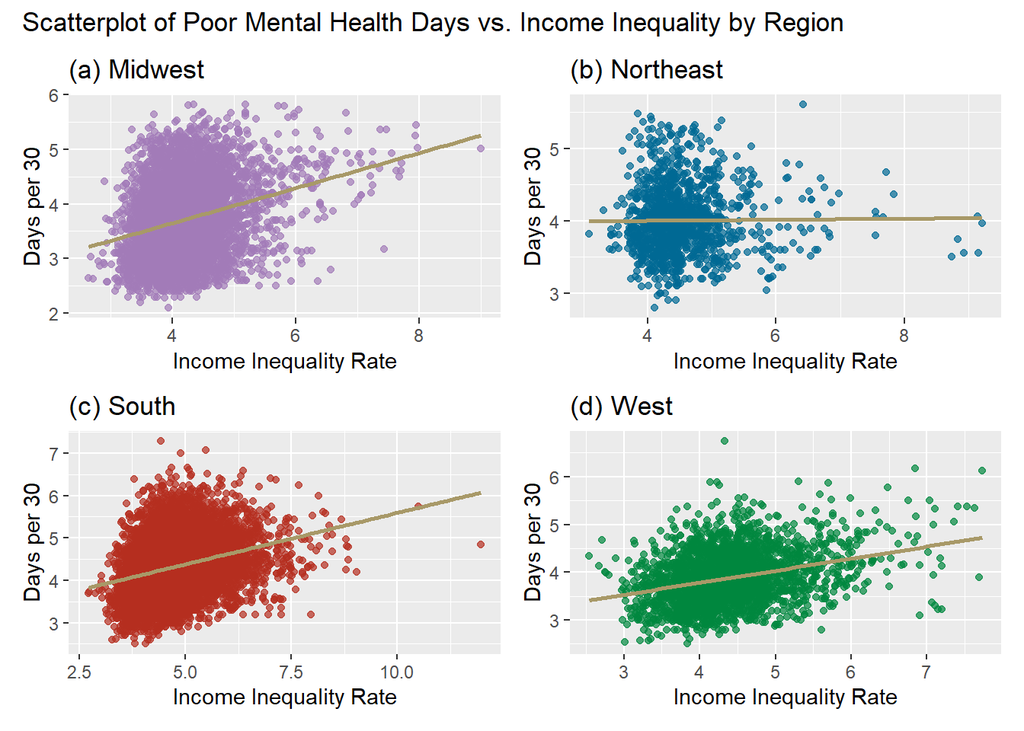

```r
# data: use ranked_MW, ranked_NE, ranked_SO, ranked_WE

rgb_colors <- c("#A27BB8", "#006994", "#B52E1F", "#00873E")

#-- mental_health_days --#

p1 <- ggplot(ranked_MW, aes(y=mental_health_days, x=inequality)) +
  geom_point(show.legend = F, alpha = .7, color = rgb_colors[1]) +
  geom_smooth(formula = y ~ x, method=lm, se=FALSE, color="#a89968") +
  labs(title = paste("(a) Midwest"),
       y = 'Days per 30', x = 'Income Inequality Rate')

p2 <- ggplot(ranked_NE, aes(y=mental_health_days, x=inequality)) +
  geom_point(show.legend = F, alpha = .7, color = rgb_colors[2]) +
  geom_smooth(formula = y ~ x, method=lm, se=FALSE, color="#a89968") +
  labs(title = paste("(b) Northeast"),
       y = 'Days per 30', x = 'Income Inequality Rate')

p3 <- ggplot(ranked_SO, aes(y=mental_health_days, x=inequality)) +
  geom_point(show.legend = F, alpha = .7, color = rgb_colors[3]) +
  geom_smooth(formula = y ~ x, method=lm, se=FALSE, color="#a89968") +
  labs(title = paste("(c) South"),
       y = 'Days per 30', x = 'Income Inequality Rate')

p4 <- ggplot(ranked_WE, aes(y=mental_health_days, x=inequality)) +
  geom_point(show.legend = F, alpha = .7, color = rgb_colors[4]) +
  geom_smooth(formula = y ~ x, method=lm, se=FALSE, color="#a89968") +
  labs(title = paste("(d) West"),
       y = 'Days per 30', x = 'Income Inequality Rate')

p_regions_1 <- (p1 + p2)/(p3 + p4) + plot_annotation(title = "Scatterplot of Poor Mental Health Days vs. Income Inequality by Region")
p_regions_1
```

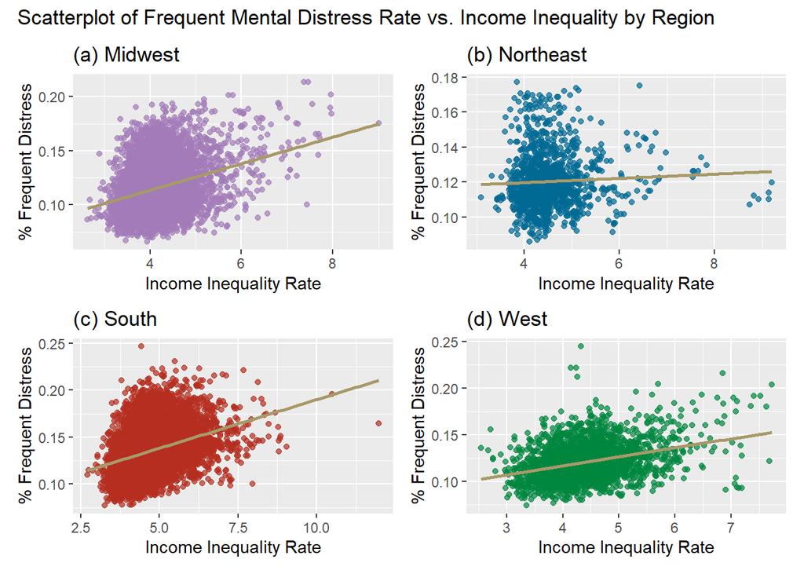

```r
#-- mental_distress_rate --#

p1 <- ggplot(ranked_MW, aes(y=mental_distress_rate, x=inequality)) +
  geom_point(show.legend = F, alpha = .7, color = rgb_colors[1]) +
  geom_smooth(formula = y ~ x, method=lm, se=FALSE, color="#a89968") +
  labs(title = paste("(a) Midwest"),
       y = '% Frequent Distress', x = 'Income Inequality Rate')

p2 <- ggplot(ranked_NE, aes(y=mental_distress_rate, x=inequality)) +
  geom_point(show.legend = F, alpha = .7, color = rgb_colors[2]) +
  geom_smooth(formula = y ~ x, method=lm, se=FALSE, color="#a89968") +
  labs(title = paste("(b) Northeast"),
       y = '% Frequent Distress', x = 'Income Inequality Rate')

p3 <- ggplot(ranked_SO, aes(y=mental_distress_rate, x=inequality)) +
  geom_point(show.legend = F, alpha = .7, color = rgb_colors[3]) +
  geom_smooth(formula = y ~ x, method=lm, se=FALSE, color="#a89968") +
  labs(title = paste("(c) South"),
       y = '% Frequent Distress', x = 'Income Inequality Rate')

p4 <- ggplot(ranked_WE, aes(y=mental_distress_rate, x=inequality)) +
  geom_point(show.legend = F, alpha = .7, color = rgb_colors[4]) +
  geom_smooth(formula = y ~ x, method=lm, se=FALSE, color="#a89968") +
  labs(title = paste("(d) West"),
       y = '% Frequent Distress', x = 'Income Inequality Rate')

p_regions_2 <- (p1 + p2)/(p3 + p4) + plot_annotation(title = "Scatterplot of Frequent Mental Distress Rate vs. Income Inequality by Region")
p_regions_2
```

At this point in the EDA, it became clear that geographic differences in the relationship between mental health and inequality were important. These results justified our decision to focus on the differences by region.

## Boxplots

To better show the relationship between the economic variables and mental health in different regions of the United States, we generated boxplots of the data by region. Analyzing the economic inequality and mental health of people by region can more clearly assess whether the relationship varies by geography than direct analysis of the whole country.

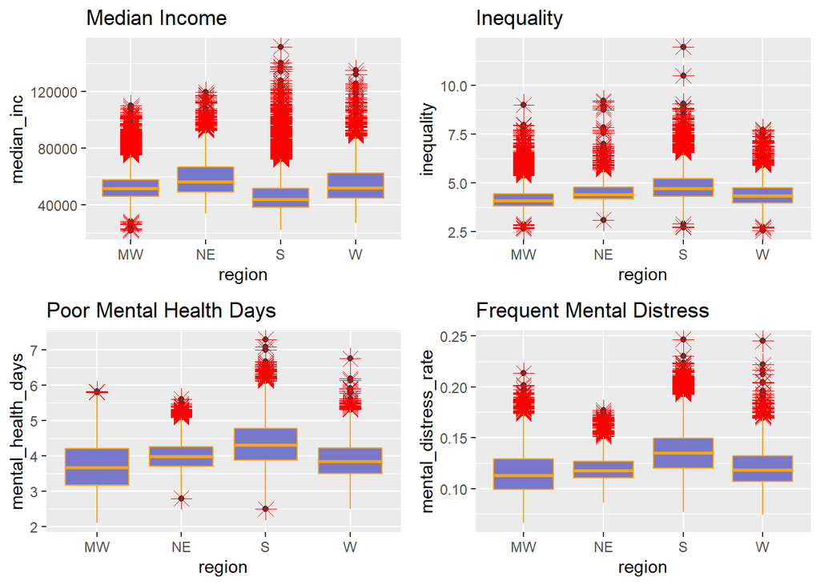

```r
# Characterization of median household income of four regions
b1 <- ggplot(ranked, aes(x=region_abb, y=median_inc)) +
  geom_boxplot() +
  geom_boxplot(colour="orange",fill="#7777cc",outlier.colour="red",outlier.shape=8, outlier.size=4) +
  labs(title="Median Income", x="region")

# Characterization of Income inequality of four regions
b2 <- ggplot(ranked, aes(x=region_abb, y=inequality)) +
  geom_boxplot() +
  geom_boxplot(colour="orange",fill="#7777cc",outlier.colour="red",outlier.shape=8, outlier.size=4) +
  labs(title="Inequality", x="region")

# Characterization of poor mental health days of four regions
b3 <- ggplot(ranked, aes(x=region_abb, y=mental_health_days)) +
  geom_boxplot() +
  geom_boxplot(colour="orange",fill="#7777cc",outlier.colour="red",outlier.shape=8, outlier.size=4) +
  labs(title="Poor Mental Health Days", x="region")

# Characterization of the Frequent mental distress rate of four regions
b4 <- ggplot(ranked, aes(x=region_abb, y=mental_distress_rate)) +
  geom_boxplot() +
  geom_boxplot(colour="orange",fill="#7777cc",outlier.colour="red",outlier.shape=8, outlier.size=4) +
  labs(title="Frequent Mental Distress", x="region")

boxplot_a <- grid.arrange(b1,b2,b3,b4, nrow=2, ncol=2) #, top = text_grob("Boxplots of Key Variables by Region", color = "black", face = "bold", size = 14))
```

Overall, what information can we conclude from these boxplots?

1. In the four U.S. regions, the Northeast has the highest median household income and the South has the lowest.
2. Income inequality is highest in the South.
3. Residents in the South also have the worst mental health, which correlates with their relatively low household income and higher levels of inequality.

As a whole, there seems to be real differences across regions in these key variables. The boxplots also indicate that these variables have outliers. As a result, we should look into the normality of the data before hypothesis testing.

## Normality

We also graphed histograms of many of the numeric variables to consider their distributions. Although none are perfectly “normal” distributions, many do seem to approximate normality. Most importantly, `mental_distress_rate` and `mental_health_days` have distributions that somewhat resemble normality. Generally, the economic variables – such as `inequality`, `median_inc`, and `unempl` – are right-skewed.

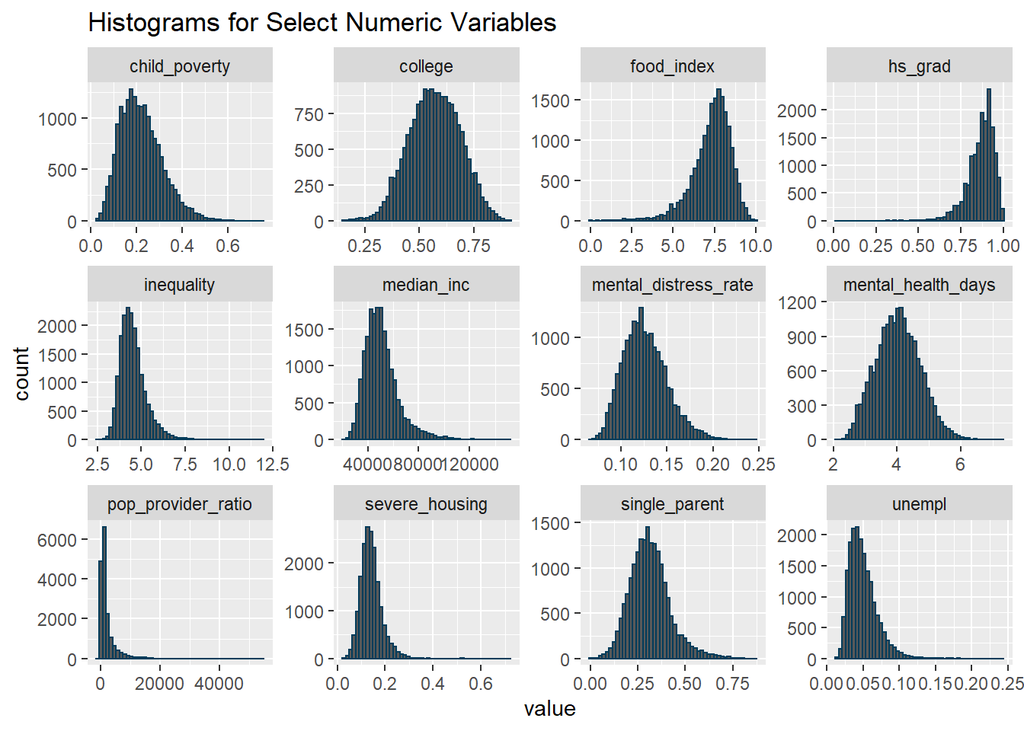

```r
# variables to plot
keep_var <- c('inequality', 'unempl', 'child_poverty', 'hs_grad', 'college', 'single_parent', 'severe_housing', 'food_index', 'mental_health_days', 'mental_distress_rate', 'median_inc', 'pop_provider_ratio')

# plot histograms
ranked[keep_var] %>%
  gather() %>%
  ggplot(aes(x=value)) +
    facet_wrap(~ key, scales = "free") +
    geom_histogram(bins=50, color = "#033C5A") +
  labs(title = "Histograms for Select Numeric Variables")
```

To complement the histograms, we also graphed Q-Q plots to assess the normality of our data. These plots compare the theoretical and sample distributions for a variable at specific quantiles. The line on each graph estimates what the variable would look like with a normal distribution.

In general, the mental health variables do not diverge too far from normality. Also, `inequality` and `median_inc` tightly follow a normal distribution until the upper range of their values, reflecting the greater spread that exists at the high end of the distribution.

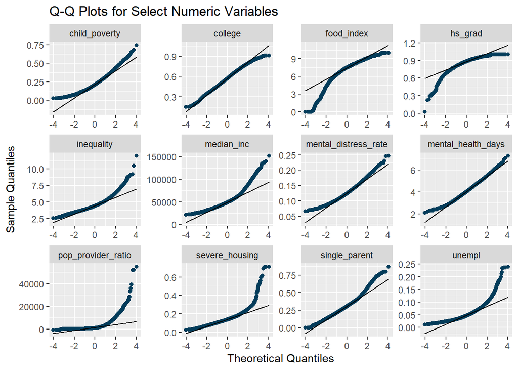

```r
# plot qq-norm plots
ranked[keep_var] %>%
  gather() %>%
  ggplot(aes(sample=value), na.rm=T) +
    facet_wrap(~ key, scales = "free") +
    stat_qq(color = "#033C5A") + stat_qq_line() + labs(title = "Q-Q Plots for Select Numeric Variables", y = "Sample Quantiles", x = "Theoretical Quantiles")
```

Despite not having a perfectly normal distribution, the sample quantiles remain relatively close to the theoretical quantiles for many of our variables. Ultimately, even if none of our variables are perfectly “normal,” few would seem to pose substantial issues during modeling. `inequality` and `median_inc` have right-tailed distributions, but without very thick tails.

## Correlation Matrix

We also assessed the correlation among the numeric variables. This helps us establish whether variables are positively or negatively associated with each other, as well as the strength of that relationship.

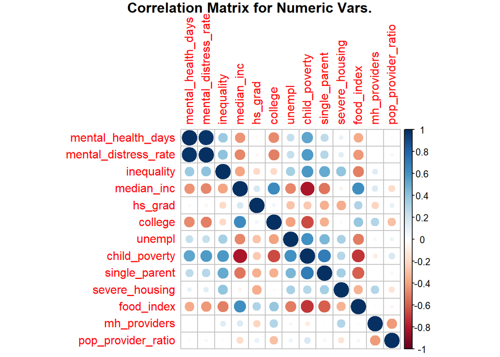

```r
# Correlation Matrices for numeric data

ranked_numeric <- subset(ranked, select = c("mental_health_days", "mental_distress_rate", "inequality", "median_inc", "hs_grad", "college", "unempl", "child_poverty","single_parent", "severe_housing", "food_index","mh_providers","pop_provider_ratio"))

a <- as.matrix(ranked_numeric)

b <- cor(a, use = "na.or.complete")

#corr_numbers <- corrplot(b, is.corr=TRUE, method="number", title="Correlation Matrix for Numeric Vars.",mar=c(0,0,1,0))

corr_numbers <- corrplot(b, is.corr=TRUE, title="Correlation Matrix for Numeric Vars.",mar=c(0,0,1,0))
```

In general, the results were not surprising. The two mental health variables are very positively correlated, and both are also positively correlated with `inequality`. In addition, `inequality` exhibited the strongest positive association with `child_poverty` and `single_parent`, and it had the strongest negative correlation with `food_index` and `median_inc`. These results make sense (remember that a higher score on the food index indicates a better food environment).

# Linear Models

We assessed two sets of models with different dependent variables. The first set of models used `mental_health_days` as the dependent variable, while the second set used `mental_distress_rate` as the dependent variable.

## Dependent variable: `mental_health_days`

We arranged several different combinations of variables to evaluate what different might make a suitable linear model with `mental_health_days` as the dependent variable. First, we regressed `mental_health_days` on the independent variable of interest – `inequality` – and a factor variable indicating the US Census Bureau region. Next, we included the factor variable `year` to control for unobserved differences over time. Third, we integrated a set of economic variables that also might relate to mental health outcomes. Finally, we added demographic variables to the model.

```r
# v1: base model by region
lm_days_1 <- lm(mental_health_days ~ inequality + region, data = ranked)
summ(lm_days_1, vifs = T)
```

| Observations | 18465 (5 missing obs. deleted) |
| --- | --- |
| Dependent variable | mental_health_days |
| Type | OLS linear regression |

| F(4,18460) | 1341.28 |
| --- | --- |
| R² | 0.23 |
| Adj. R² | 0.23 |

|  | Est. | S.E. | t val. | p | VIF |
| --- | --- | --- | --- | --- | --- |
| (Intercept) | 2.68 | 0.03 | 93.25 | 0.00 | NA |
| inequality | 0.25 | 0.01 | 37.33 | 0.00 | 1.17 |
| regionNortheast | 0.21 | 0.02 | 11.35 | 0.00 | 1.17 |
| regionSouth | 0.47 | 0.01 | 42.89 | 0.00 | 1.17 |
| regionWest | 0.12 | 0.01 | 8.40 | 0.00 | 1.17 |

Standard errors: OLS

```r
# v2: include year as factor variable
lm_days_2 <- lm(mental_health_days ~ inequality + region + year, data = ranked)
summ(lm_days_2, vifs = T)
```

| Observations | 18465 (5 missing obs. deleted) |
| --- | --- |
| Dependent variable | mental_health_days |
| Type | OLS linear regression |

| F(9,18455) | 1672.85 |
| --- | --- |
| R² | 0.45 |
| Adj. R² | 0.45 |

|  | Est. | S.E. | t val. | p | VIF |
| --- | --- | --- | --- | --- | --- |
| (Intercept) | 2.32 | 0.03 | 90.60 | 0.00 | NA |
| inequality | 0.25 | 0.01 | 44.51 | 0.00 | 1.17 |
| regionNortheast | 0.21 | 0.02 | 13.44 | 0.00 | 1.17 |
| regionSouth | 0.47 | 0.01 | 50.79 | 0.00 | 1.17 |
| regionWest | 0.12 | 0.01 | 9.83 | 0.00 | 1.17 |
| year2017 | 0.10 | 0.01 | 7.73 | 0.00 | 1.00 |
| year2018 | 0.25 | 0.01 | 19.45 | 0.00 | 1.00 |
| year2019 | 0.26 | 0.01 | 19.53 | 0.00 | 1.00 |
| year2020 | 0.49 | 0.01 | 37.50 | 0.00 | 1.00 |
| year2021 | 1.00 | 0.01 | 76.30 | 0.00 | 1.00 |

Standard errors: OLS

```r
# v3: include economic vars
lm_days_3 <- lm(mental_health_days ~ inequality + college + hs_grad + unempl
                + child_poverty + single_parent + severe_housing + food_index
                + median_inc + pop_provider_ratio
                + region + year, data = ranked)
summ(lm_days_3, vifs = T)
```

| Observations | 15741 (2729 missing obs. deleted) |
| --- | --- |
| Dependent variable | mental_health_days |
| Type | OLS linear regression |

| F(18,15722) | 1739.73 |
| --- | --- |
| R² | 0.67 |
| Adj. R² | 0.67 |

|  | Est. | S.E. | t val. | p | VIF |
| --- | --- | --- | --- | --- | --- |
| (Intercept) | 3.94 | 0.08 | 52.23 | 0.00 | NA |
| inequality | 0.05 | 0.01 | 8.49 | 0.00 | 1.91 |
| college | -0.90 | 0.04 | -21.63 | 0.00 | 2.34 |
| hs_grad | 0.27 | 0.05 | 5.73 | 0.00 | 1.42 |
| unempl | 6.49 | 0.23 | 27.69 | 0.00 | 2.18 |
| child_poverty | 0.76 | 0.09 | 8.34 | 0.00 | 6.96 |
| single_parent | -0.13 | 0.05 | -2.55 | 0.01 | 2.66 |
| severe_housing | -0.38 | 0.09 | -4.29 | 0.00 | 1.72 |
| food_index | -0.02 | 0.00 | -4.96 | 0.00 | 2.56 |
| median_inc | -0.00 | 0.00 | -28.25 | 0.00 | 3.90 |
| pop_provider_ratio | -0.00 | 0.00 | -16.86 | 0.00 | 1.18 |
| regionNortheast | 0.28 | 0.01 | 21.77 | 0.00 | 2.23 |
| regionSouth | 0.27 | 0.01 | 31.93 | 0.00 | 2.23 |
| regionWest | 0.06 | 0.01 | 4.81 | 0.00 | 2.23 |
| year2017 | 0.16 | 0.01 | 14.71 | 0.00 | 1.67 |
| year2018 | 0.37 | 0.01 | 32.97 | 0.00 | 1.67 |
| year2019 | 0.41 | 0.01 | 36.07 | 0.00 | 1.67 |
| year2020 | 0.70 | 0.01 | 58.55 | 0.00 | 1.67 |
| year2021 | 1.27 | 0.01 | 102.28 | 0.00 | 1.67 |

Standard errors: OLS

```r
# v4: include demographic vars
lm_days_4 <- lm(mental_health_days ~ inequality + college + hs_grad + unempl
                + child_poverty + single_parent + severe_housing + food_index
                + median_inc + pop_provider_ratio
                + pop + pct_below18 + pct_female + pct_rural
                + pct_black + pct_native_am + pct_asian + pct_pacific + pct_hispanic + pct_white
                + region + year, data = ranked)
summ(lm_days_4, vifs = T)
```

| Observations | 15728 (2742 missing obs. deleted) |
| --- | --- |
| Dependent variable | mental_health_days |
| Type | OLS linear regression |

| F(28,15699) | 1598.75 |
| --- | --- |
| R² | 0.74 |
| Adj. R² | 0.74 |

|  | Est. | S.E. | t val. | p | VIF |
| --- | --- | --- | --- | --- | --- |
| (Intercept) | 5.86 | 0.32 | 18.59 | 0.00 | NA |
| inequality | 0.07 | 0.01 | 13.49 | 0.00 | 2.01 |
| college | -1.64 | 0.04 | -38.79 | 0.00 | 3.12 |
| hs_grad | 0.15 | 0.04 | 3.46 | 0.00 | 1.52 |
| unempl | 5.19 | 0.21 | 24.50 | 0.00 | 2.25 |
| child_poverty | 1.34 | 0.08 | 16.05 | 0.00 | 7.54 |
| single_parent | 0.39 | 0.05 | 7.26 | 0.00 | 3.90 |
| severe_housing | 0.39 | 0.09 | 4.30 | 0.00 | 2.17 |
| food_index | -0.04 | 0.00 | -8.54 | 0.00 | 3.07 |
| median_inc | -0.00 | 0.00 | -15.86 | 0.00 | 5.51 |
| pop_provider_ratio | -0.00 | 0.00 | -6.53 | 0.00 | 1.28 |
| pop | 0.00 | 0.00 | 8.59 | 0.00 | 1.49 |
| pct_below18 | 0.90 | 0.11 | 8.16 | 0.00 | 1.76 |
| pct_female | 3.39 | 0.16 | 20.90 | 0.00 | 1.47 |
| pct_rural | -0.22 | 0.01 | -15.29 | 0.00 | 2.40 |
| pct_black | -4.78 | 0.31 | -15.32 | 0.00 | 273.52 |
| pct_native_am | -4.13 | 0.33 | -12.57 | 0.00 | 61.64 |
| pct_asian | -3.95 | 0.36 | -10.93 | 0.00 | 14.94 |
| pct_pacific | -12.20 | 1.05 | -11.67 | 0.00 | 3.04 |
| pct_hispanic | -4.97 | 0.30 | -16.48 | 0.00 | 216.22 |
| pct_white | -3.65 | 0.31 | -11.62 | 0.00 | 516.34 |
| regionNortheast | 0.25 | 0.01 | 20.91 | 0.00 | 3.44 |
| regionSouth | 0.32 | 0.01 | 38.78 | 0.00 | 3.44 |
| regionWest | 0.19 | 0.01 | 17.58 | 0.00 | 3.44 |
| year2017 | 0.16 | 0.01 | 16.51 | 0.00 | 1.98 |
| year2018 | 0.38 | 0.01 | 38.05 | 0.00 | 1.98 |
| year2019 | 0.44 | 0.01 | 42.46 | 0.00 | 1.98 |
| year2020 | 0.72 | 0.01 | 67.04 | 0.00 | 1.98 |
| year2021 | 1.32 | 0.01 | 114.25 | 0.00 | 1.98 |

Standard errors: OLS

For the first (base) model, the equations for each region are as follows:

- `regionMidwest`: `mental_health_days` = 2.676 + 0.247 * `inequality`
- `regionNortheast`: `mental_health_days` = 2.676 + 0.212 + 0.247 * `inequality`
- `regionSouth`: `mental_health_days` = 2.676 + 0.472 + 0.247 * `inequality`
- `regionWest`: `mental_health_days` = 2.676 + 0.121 + 0.247 * `inequality`

Similar to the initial results from our EDA, the Midwest region (which is included in the intercept) has the lowest estimate for mental_health_days and the South has the highest. All the coefficients are statistically significant. Our measure for income inequality is statistically significant at the 0.001 level with a coefficient of 0.247, indicating a positive association with poor mental health days.

After including the year factor variables, the economic variables, and the demographic variables, the coefficients on all variables remained statistically significant. However, the coefficient on `inequality` declined to 0.072 in the fourth model (which included the most variables). This suggests that the base model exhibited omitted variable bias that the fuller model at least partially addressed. The South still had the largest coefficient among the `region` factor variables.

In general, The other economic variables demonstrated relationships with mental health that were expected. For instance, higher rates for`unempl`, `child_poverty`, `single_parent`, and `severe_housing` were all associated with worse mental health. A better food environment, higher median household incomes, and having a larger percentage of the population with some post-secondary education were associated with better mental health. Interestingly, a higher high-school graduation rate was positively associated with poor mental health.

The following table shows the regression results for models 1, 2, 3, and 4 (from above).

```r
tables_a_c <- c("(Intercept)", "inequality",
                       "Northeast" = "regionNortheast", "South" = "regionSouth", "West" = "regionWest",
                       "college", "hs_grad", "unempl", "child_poverty", "single_parent",
                       "severe_housing", "food_index", "median_inc",
                       "pop_provider_ratio", "pop")

export_summs(lm_days_1, lm_days_2, lm_days_3, lm_days_4,
             #error_format = "({p.value})",
             statistics = c(Num.obs = "nobs", R2 = "r.squared", adj.R2 = "adj.r.squared"),
             model.names = c("1", "2", "3", "4"),
             coefs = tables_a_c
             )
```

|  | 1 | 2 | 3 | 4 |
| --- | --- | --- | --- | --- |
| (Intercept) | 2.68 *** | 2.32 *** | 3.94 *** | 5.86 *** |
|  | (0.03) | (0.03) | (0.08) | (0.32) |
| inequality | 0.25 *** | 0.25 *** | 0.05 *** | 0.07 *** |
|  | (0.01) | (0.01) | (0.01) | (0.01) |
| Northeast | 0.21 *** | 0.21 *** | 0.28 *** | 0.25 *** |
|  | (0.02) | (0.02) | (0.01) | (0.01) |
| South | 0.47 *** | 0.47 *** | 0.27 *** | 0.32 *** |
|  | (0.01) | (0.01) | (0.01) | (0.01) |
| West | 0.12 *** | 0.12 *** | 0.06 *** | 0.19 *** |
|  | (0.01) | (0.01) | (0.01) | (0.01) |
| college |  |  | -0.90 *** | -1.64 *** |
|  |  |  | (0.04) | (0.04) |
| hs_grad |  |  | 0.27 *** | 0.15 *** |
|  |  |  | (0.05) | (0.04) |
| unempl |  |  | 6.49 *** | 5.19 *** |
|  |  |  | (0.23) | (0.21) |
| child_poverty |  |  | 0.76 *** | 1.34 *** |
|  |  |  | (0.09) | (0.08) |
| single_parent |  |  | -0.13 * | 0.39 *** |
|  |  |  | (0.05) | (0.05) |
| severe_housing |  |  | -0.38 *** | 0.39 *** |
|  |  |  | (0.09) | (0.09) |
| food_index |  |  | -0.02 *** | -0.04 *** |
|  |  |  | (0.00) | (0.00) |
| median_inc |  |  | -0.00 *** | -0.00 *** |
|  |  |  | (0.00) | (0.00) |
| pop_provider_ratio |  |  | -0.00 *** | -0.00 *** |
|  |  |  | (0.00) | (0.00) |
| pop |  |  |  | 0.00 *** |
|  |  |  |  | (0.00) |
| Num.obs | 18465 | 18465 | 15741 | 15728 |
| R2 | 0.23 | 0.45 | 0.67 | 0.74 |
| adj.R2 | 0.23 | 0.45 | 0.67 | 0.74 |
| *** p < 0.001; ** p < 0.01; * p < 0.05. |  |  |  |  |

After adding so many different variables, we want to check for multicollinearity. Thus, we also evaluated the VIF for each model.

The majority of VIF results are below 5, which is acceptable. However, several variables have extremely high VIFs – specifically, the demographic variables for ethnic groups. The following model removed `pct_white`, which improved the VIFs significantly. It also removed `child_poverty`, which had a relatively high VIF of 7.536. After removing the collinear variables, the VIFs of the model were all below 5.

```r
# v5: remove vars to reduce vif
lm_days_5 <- lm(mental_health_days ~ inequality + college + hs_grad + unempl
                + single_parent + severe_housing + food_index
                + pop + pop_provider_ratio + pct_female + pct_rural + pct_below18
                + pct_black + pct_native_am + pct_asian + pct_pacific + pct_hispanic
                + region + year, data = ranked)
summ(lm_days_5, vifs = T)
```

| Observations | 15728 (2742 missing obs. deleted) |
| --- | --- |
| Dependent variable | mental_health_days |
| Type | OLS linear regression |

| F(25,15702) | 1623.59 |
| --- | --- |
| R² | 0.72 |
| Adj. R² | 0.72 |

|  | Est. | S.E. | t val. | p | VIF |
| --- | --- | --- | --- | --- | --- |
| (Intercept) | 2.39 | 0.09 | 25.39 | 0.00 | NA |
| inequality | 0.12 | 0.01 | 22.51 | 0.00 | 1.81 |
| college | -2.19 | 0.04 | -55.69 | 0.00 | 2.52 |
| hs_grad | -0.04 | 0.04 | -0.80 | 0.42 | 1.50 |
| unempl | 6.37 | 0.21 | 30.12 | 0.00 | 2.08 |
| single_parent | 0.92 | 0.05 | 17.60 | 0.00 | 3.51 |
| severe_housing | 0.47 | 0.09 | 5.09 | 0.00 | 2.16 |
| food_index | -0.10 | 0.00 | -25.17 | 0.00 | 2.45 |
| pop | 0.00 | 0.00 | 9.14 | 0.00 | 1.49 |
| pop_provider_ratio | -0.00 | 0.00 | -7.84 | 0.00 | 1.27 |
| pct_female | 4.17 | 0.17 | 25.11 | 0.00 | 1.43 |
| pct_rural | -0.13 | 0.01 | -9.32 | 0.00 | 2.23 |
| pct_below18 | 0.48 | 0.11 | 4.25 | 0.00 | 1.71 |
| pct_black | -1.35 | 0.04 | -38.57 | 0.00 | 3.22 |
| pct_native_am | -0.65 | 0.06 | -11.14 | 0.00 | 1.79 |
| pct_asian | -1.13 | 0.14 | -7.81 | 0.00 | 2.23 |
| pct_pacific | -1.84 | 0.75 | -2.47 | 0.01 | 1.45 |
| pct_hispanic | -1.43 | 0.03 | -48.60 | 0.00 | 1.91 |
| regionNortheast | 0.18 | 0.01 | 15.24 | 0.00 | 3.02 |
| regionSouth | 0.32 | 0.01 | 39.22 | 0.00 | 3.02 |
| regionWest | 0.14 | 0.01 | 12.27 | 0.00 | 3.02 |
| year2017 | 0.16 | 0.01 | 15.98 | 0.00 | 1.89 |
| year2018 | 0.39 | 0.01 | 37.62 | 0.00 | 1.89 |
| year2019 | 0.44 | 0.01 | 41.84 | 0.00 | 1.89 |
| year2020 | 0.72 | 0.01 | 65.10 | 0.00 | 1.89 |
| year2021 | 1.33 | 0.01 | 112.53 | 0.00 | 1.89 |

Standard errors: OLS

To permit the coefficients for `inequality` to differ by region, we included an interaction term between `inequality` and `region`.

```r
# v6: base model by region with interaction terms
lm_days_6 <- lm(mental_health_days ~ inequality*region, data = ranked)
summ(lm_days_6)
```

| Observations | 18465 (5 missing obs. deleted) |
| --- | --- |
| Dependent variable | mental_health_days |
| Type | OLS linear regression |

| F(7,18457) | 787.92 |
| --- | --- |
| R² | 0.23 |
| Adj. R² | 0.23 |

|  | Est. | S.E. | t val. | p |
| --- | --- | --- | --- | --- |
| (Intercept) | 2.36 | 0.06 | 40.88 | 0.00 |
| inequality | 0.32 | 0.01 | 23.45 | 0.00 |
| regionNortheast | 1.61 | 0.13 | 12.29 | 0.00 |
| regionSouth | 0.80 | 0.07 | 11.17 | 0.00 |
| regionWest | 0.41 | 0.10 | 4.20 | 0.00 |
| inequality:regionNortheast | -0.31 | 0.03 | -10.80 | 0.00 |
| inequality:regionSouth | -0.08 | 0.02 | -4.83 | 0.00 |
| inequality:regionWest | -0.07 | 0.02 | -3.10 | 0.00 |

Standard errors: OLS

The equations for each region with interaction terms are as follows:

- `regionMidwest`: `mental_health_days` = 2.364 + 0.321 * `inequality`
- `regionNortheast`: `mental_health_days` = 2.364 + 1.613 + (0.321 + -0.314) * `inequality`
- `regionSouth`: `mental_health_days` = 2.364 + 0.803 + (0.321 + -0.079) * `inequality`
- `regionWest`: `mental_health_days` = 2.364 + 0.41 + (0.321 + -0.069) * `inequality`

These results suggest that the strength of the relationship between `mental_health_days` and `inequality` differs by region. In fact, while the Northeast has the highest estimated amount of poor mental health (see the intercept), the coefficient on `inequality` is near zero. Conversely, the Midwest has the lowest estimate of poor mental health, while exhibiting the strongest association. All the independent variables are statistically significant.

```r
# v7: larger model with interaction terms
lm_days_7 <- lm(mental_health_days ~ inequality*region + college + hs_grad + unempl
                + single_parent + severe_housing + food_index
                + pop + pop_provider_ratio + pct_female + pct_rural + pct_below18
                + pct_black + pct_native_am + pct_asian + pct_pacific + pct_hispanic
                + year, data = ranked)
summ(lm_days_7)
```

| Observations | 15728 (2742 missing obs. deleted) |
| --- | --- |
| Dependent variable | mental_health_days |
| Type | OLS linear regression |

| F(28,15699) | 1460.05 |
| --- | --- |
| R² | 0.72 |
| Adj. R² | 0.72 |

|  | Est. | S.E. | t val. | p |
| --- | --- | --- | --- | --- |
| (Intercept) | 2.13 | 0.10 | 20.84 | 0.00 |
| inequality | 0.18 | 0.01 | 17.78 | 0.00 |
| regionNortheast | 0.45 | 0.08 | 5.52 | 0.00 |
| regionSouth | 0.73 | 0.05 | 14.72 | 0.00 |
| regionWest | 0.19 | 0.06 | 2.86 | 0.00 |
| college | -2.19 | 0.04 | -55.86 | 0.00 |
| hs_grad | -0.03 | 0.04 | -0.68 | 0.50 |
| unempl | 6.39 | 0.21 | 30.26 | 0.00 |
| single_parent | 0.92 | 0.05 | 17.50 | 0.00 |
| severe_housing | 0.44 | 0.09 | 4.74 | 0.00 |
| food_index | -0.10 | 0.00 | -24.87 | 0.00 |
| pop | 0.00 | 0.00 | 8.84 | 0.00 |
| pop_provider_ratio | -0.00 | 0.00 | -8.03 | 0.00 |
| pct_female | 4.06 | 0.17 | 24.40 | 0.00 |
| pct_rural | -0.12 | 0.01 | -8.54 | 0.00 |
| pct_below18 | 0.63 | 0.11 | 5.50 | 0.00 |
| pct_black | -1.31 | 0.04 | -36.96 | 0.00 |
| pct_native_am | -0.76 | 0.06 | -12.65 | 0.00 |
| pct_asian | -1.25 | 0.15 | -8.59 | 0.00 |
| pct_pacific | -1.53 | 0.75 | -2.05 | 0.04 |
| pct_hispanic | -1.44 | 0.03 | -48.51 | 0.00 |
| year2017 | 0.16 | 0.01 | 16.04 | 0.00 |
| year2018 | 0.39 | 0.01 | 37.72 | 0.00 |
| year2019 | 0.44 | 0.01 | 41.95 | 0.00 |
| year2020 | 0.72 | 0.01 | 65.34 | 0.00 |
| year2021 | 1.33 | 0.01 | 112.82 | 0.00 |
| inequality:regionNortheast | -0.06 | 0.02 | -3.40 | 0.00 |
| inequality:regionSouth | -0.09 | 0.01 | -8.26 | 0.00 |
| inequality:regionWest | -0.01 | 0.01 | -0.81 | 0.42 |

Standard errors: OLS

```r
vif(lm_days_7)
```

```
            inequality            regionNortheast
                  6.91                      61.76
           regionSouth                 regionWest
                 78.81                      62.04
               college                    hs_grad
                  2.52                       1.50
                unempl              single_parent
                  2.09                       3.52
        severe_housing                 food_index
                  2.17                       2.47
                   pop         pop_provider_ratio
                  1.50                       1.28
            pct_female                  pct_rural
                  1.44                       2.25
           pct_below18                  pct_black
                  1.77                       3.29
         pct_native_am                  pct_asian
                  1.91                       2.27
           pct_pacific               pct_hispanic
                  1.45                       1.95
              year2017                   year2018
                  1.74                       1.82
              year2019                   year2020
                  2.07                       2.24
              year2021 inequality:regionNortheast
                  2.36                      65.24
inequality:regionSouth      inequality:regionWest
                 99.90                      66.10
```

The equations for the fuller models with interaction terms are below, where V<sub>c</sub> is a vector of additional control variables:

- `regionMidwest`: `mental_health_days` = 2.13 + 0.182 * `inequality` + V<sub>c</sub>
- `regionNortheast`: `mental_health_days` = 2.13 + 0.448 + (0.182 - 0.0616) * `inequality` + V<sub>c</sub>
- `regionSouth`: `mental_health_days` = 2.13 + 0.734 + (0.182 - 0.0944) * `inequality` + V<sub>c</sub>
- `regionWest`: `mental_health_days` = 2.13 + 0.186 + (0.182 - 0.0121) * `inequality` + V<sub>c</sub>

After including the set of control variables, the coefficients for `inequality` still differ by region. However, now it appears that the South has the weakest association between `inequality` and `mental_health_days` and the Midwest still has the strongest.

The following table shows the regression results for models 1, 5, 6, and 7 (from above).

```r
tables_b_d <- c("(Intercept)", "inequality",
                       "Northeast" = "regionNortheast", "South" = "regionSouth", "West" = "regionWest",
                       "inequality:NE" = "inequality:regionNortheast",
                       "inequality:SO" = "inequality:regionSouth",
                       "inequality:WE" = "inequality:regionWest",
                       "college", "hs_grad", "unempl", "single_parent",
                        "severe_housing", "food_index")

export_summs(lm_days_1, lm_days_5, lm_days_6, lm_days_7,
             statistics = c(Num.obs = "nobs", R2 = "r.squared", adj.R2 = "adj.r.squared"),
             model.names = c("1", "5", "6", "7"),
             coefs = tables_b_d
             )
```

|  | 1 | 5 | 6 | 7 |
| --- | --- | --- | --- | --- |
| (Intercept) | 2.68 *** | 2.39 *** | 2.36 *** | 2.13 *** |
|  | (0.03) | (0.09) | (0.06) | (0.10) |
| inequality | 0.25 *** | 0.12 *** | 0.32 *** | 0.18 *** |
|  | (0.01) | (0.01) | (0.01) | (0.01) |
| Northeast | 0.21 *** | 0.18 *** | 1.61 *** | 0.45 *** |
|  | (0.02) | (0.01) | (0.13) | (0.08) |
| South | 0.47 *** | 0.32 *** | 0.80 *** | 0.73 *** |
|  | (0.01) | (0.01) | (0.07) | (0.05) |
| West | 0.12 *** | 0.14 *** | 0.41 *** | 0.19 ** |
|  | (0.01) | (0.01) | (0.10) | (0.06) |
| inequality:NE |  |  | -0.31 *** | -0.06 *** |
|  |  |  | (0.03) | (0.02) |
| inequality:SO |  |  | -0.08 *** | -0.09 *** |
|  |  |  | (0.02) | (0.01) |
| inequality:WE |  |  | -0.07 ** | -0.01 |
|  |  |  | (0.02) | (0.01) |
| college |  | -2.19 *** |  | -2.19 *** |
|  |  | (0.04) |  | (0.04) |
| hs_grad |  | -0.04 |  | -0.03 |
|  |  | (0.04) |  | (0.04) |
| unempl |  | 6.37 *** |  | 6.39 *** |
|  |  | (0.21) |  | (0.21) |
| single_parent |  | 0.92 *** |  | 0.92 *** |
|  |  | (0.05) |  | (0.05) |
| severe_housing |  | 0.47 *** |  | 0.44 *** |
|  |  | (0.09) |  | (0.09) |
| food_index |  | -0.10 *** |  | -0.10 *** |
|  |  | (0.00) |  | (0.00) |
| Num.obs | 18465 | 15728 | 18465 | 15728 |
| R2 | 0.23 | 0.72 | 0.23 | 0.72 |
| adj.R2 | 0.23 | 0.72 | 0.23 | 0.72 |
| *** p < 0.001; ** p < 0.01; * p < 0.05. |  |  |  |  |

## Dependent variable: `mental_distress_rate`

Next, we considered a series of linear models with `mental_distress_rate` as the dependent variable. In the following models, we used different combinations of variables to find the most suitable model.

```r
# x1: base model by region
lm_rate_1 <- lm(mental_distress_rate ~ inequality + region, data = ranked)
summ(lm_rate_1)
```

| Observations | 18465 (5 missing obs. deleted) |
| --- | --- |
| Dependent variable | mental_distress_rate |
| Type | OLS linear regression |

| F(4,18460) | 1465.34 |
| --- | --- |
| R² | 0.24 |
| Adj. R² | 0.24 |

|  | Est. | S.E. | t val. | p |
| --- | --- | --- | --- | --- |
| (Intercept) | 0.07 | 0.00 | 75.33 | 0.00 |
| inequality | 0.01 | 0.00 | 45.00 | 0.00 |
| regionNortheast | 0.00 | 0.00 | 1.66 | 0.10 |
| regionSouth | 0.01 | 0.00 | 37.84 | 0.00 |
| regionWest | 0.00 | 0.00 | 5.32 | 0.00 |

Standard errors: OLS

```r
# x2: include year as factor variable
lm_rate_2 <- lm(mental_distress_rate ~ inequality + region + year, data = ranked)
summ(lm_rate_2)
```

| Observations | 18465 (5 missing obs. deleted) |
| --- | --- |
| Dependent variable | mental_distress_rate |
| Type | OLS linear regression |

| F(9,18455) | 2255.52 |
| --- | --- |
| R² | 0.52 |
| Adj. R² | 0.52 |

|  | Est. | S.E. | t val. | p |
| --- | --- | --- | --- | --- |
| (Intercept) | 0.06 | 0.00 | 73.30 | 0.00 |
| inequality | 0.01 | 0.00 | 57.08 | 0.00 |
| regionNortheast | 0.00 | 0.00 | 2.07 | 0.04 |
| regionSouth | 0.01 | 0.00 | 47.68 | 0.00 |
| regionWest | 0.00 | 0.00 | 6.56 | 0.00 |
| year2017 | 0.00 | 0.00 | 10.07 | 0.00 |
| year2018 | 0.01 | 0.00 | 23.01 | 0.00 |
| year2019 | 0.01 | 0.00 | 23.12 | 0.00 |
| year2020 | 0.02 | 0.00 | 42.03 | 0.00 |
| year2021 | 0.04 | 0.00 | 92.94 | 0.00 |

Standard errors: OLS

```r
# x3: include economic vars
lm_rate_3 <- lm(mental_distress_rate ~ inequality + college + hs_grad + unempl
                + child_poverty + single_parent + severe_housing + food_index
                + median_inc + pop_provider_ratio
                + region + year, data = ranked)
summ(lm_rate_3)
```

| Observations | 15741 (2729 missing obs. deleted) |
| --- | --- |
| Dependent variable | mental_distress_rate |
| Type | OLS linear regression |

| F(18,15722) | 2945.24 |
| --- | --- |
| R² | 0.77 |
| Adj. R² | 0.77 |

|  | Est. | S.E. | t val. | p |
| --- | --- | --- | --- | --- |
| (Intercept) | 0.12 | 0.00 | 57.82 | 0.00 |
| inequality | 0.00 | 0.00 | 11.50 | 0.00 |
| college | -0.03 | 0.00 | -25.61 | 0.00 |
| hs_grad | 0.01 | 0.00 | 5.37 | 0.00 |
| unempl | 0.18 | 0.01 | 27.35 | 0.00 |
| child_poverty | 0.04 | 0.00 | 15.01 | 0.00 |
| single_parent | -0.00 | 0.00 | -2.93 | 0.00 |
| severe_housing | 0.01 | 0.00 | 2.13 | 0.03 |
| food_index | -0.00 | 0.00 | -12.51 | 0.00 |
| median_inc | -0.00 | 0.00 | -32.68 | 0.00 |
| pop_provider_ratio | -0.00 | 0.00 | -14.87 | 0.00 |
| regionNortheast | 0.00 | 0.00 | 12.80 | 0.00 |
| regionSouth | 0.01 | 0.00 | 28.41 | 0.00 |
| regionWest | -0.00 | 0.00 | -0.03 | 0.97 |
| year2017 | 0.01 | 0.00 | 19.26 | 0.00 |
| year2018 | 0.01 | 0.00 | 41.57 | 0.00 |
| year2019 | 0.02 | 0.00 | 46.23 | 0.00 |
| year2020 | 0.02 | 0.00 | 73.00 | 0.00 |
| year2021 | 0.05 | 0.00 | 135.98 | 0.00 |

Standard errors: OLS

```r
# x4: include demographic vars
lm_rate_4 <- lm(mental_distress_rate ~ inequality + college + hs_grad + unempl
                + child_poverty + single_parent + severe_housing + food_index
                + median_inc + pop_provider_ratio
                + pop + pct_below18 + pct_female + pct_rural
                + pct_black + pct_native_am + pct_asian + pct_pacific + pct_hispanic + pct_white
                + region + year, data = ranked)
summ(lm_rate_4)
```

| Observations | 15728 (2742 missing obs. deleted) |
| --- | --- |
| Dependent variable | mental_distress_rate |
| Type | OLS linear regression |

| F(28,15699) | 2565.65 |
| --- | --- |
| R² | 0.82 |
| Adj. R² | 0.82 |

|  | Est. | S.E. | t val. | p |
| --- | --- | --- | --- | --- |
| (Intercept) | 0.16 | 0.01 | 17.41 | 0.00 |
| inequality | 0.00 | 0.00 | 17.91 | 0.00 |
| college | -0.05 | 0.00 | -38.82 | 0.00 |
| hs_grad | 0.01 | 0.00 | 4.28 | 0.00 |
| unempl | 0.14 | 0.01 | 22.69 | 0.00 |
| child_poverty | 0.05 | 0.00 | 22.28 | 0.00 |
| single_parent | 0.01 | 0.00 | 6.82 | 0.00 |
| severe_housing | 0.02 | 0.00 | 8.86 | 0.00 |
| food_index | -0.00 | 0.00 | -12.71 | 0.00 |
| median_inc | -0.00 | 0.00 | -22.19 | 0.00 |
| pop_provider_ratio | -0.00 | 0.00 | -6.50 | 0.00 |
| pop | 0.00 | 0.00 | 5.82 | 0.00 |
| pct_below18 | 0.05 | 0.00 | 15.30 | 0.00 |
| pct_female | 0.10 | 0.00 | 20.74 | 0.00 |
| pct_rural | -0.00 | 0.00 | -9.57 | 0.00 |
| pct_black | -0.12 | 0.01 | -13.65 | 0.00 |
| pct_native_am | -0.09 | 0.01 | -9.74 | 0.00 |
| pct_asian | -0.10 | 0.01 | -9.64 | 0.00 |
| pct_pacific | -0.32 | 0.03 | -10.83 | 0.00 |
| pct_hispanic | -0.13 | 0.01 | -14.99 | 0.00 |
| pct_white | -0.09 | 0.01 | -10.41 | 0.00 |
| regionNortheast | 0.00 | 0.00 | 14.24 | 0.00 |
| regionSouth | 0.01 | 0.00 | 36.50 | 0.00 |
| regionWest | 0.00 | 0.00 | 12.38 | 0.00 |
| year2017 | 0.01 | 0.00 | 21.24 | 0.00 |
| year2018 | 0.01 | 0.00 | 46.55 | 0.00 |
| year2019 | 0.02 | 0.00 | 51.97 | 0.00 |
| year2020 | 0.02 | 0.00 | 81.19 | 0.00 |
| year2021 | 0.05 | 0.00 | 148.82 | 0.00 |

Standard errors: OLS

```r
#From the first model, we can see that the equations for each region are below:
# regionMidwest: mental_distress_rate = 0.073 + 0.010 * inequality
# regionNortheast: mental_distress_rate = 0.073 + 0.001 + 0.010 * inequality
# regionSouth: mental_distress_rate = 0.073 + 0.014 + 0.010 * inequality
# regionWest: mental_distress_rate = 0.073 + 0.002 + 0.010 * inequality
# From above, we can see that the Midwest has the lowest estimate for mental_distress_rate, and the South has the highest estimate. The northeast region shows not significant, others are significant.
# After including the year factor variables, the economic variables, and the demographic variables, the coefficients on all variables remained significant. The northeast continue to show not significant. However, the coefficient on 'inequality' declined from 0.0101 to 0.00274 in the fourth model, which suggests that the base model exhibited omitted variable bias that the fuller model at least partially addressed. The South region still has the largest coefficient among the 'region' factor variables.
```

From the first model, we can see that the equations for each region are below:

- `regionMidwest`: `mental_distress_rate` = 0.073 + 0.010 * `inequality`
- `regionNortheast`: `mental_distress_rate` = 0.073 + 0.001 + 0.010 * `inequality`
- `regionSouth`: `mental_distress_rate` = 0.073 + 0.014 + 0.010 * `inequality`
- `regionWest`: `mental_distress_rate` = 0.073 + 0.002 + 0.010 * `inequality`

From above, we can see that the Midwest has the lowest estimate for `mental_distress_rate`, and the South has the highest estimate. The Northeast region shows not significant, others are significant.

After including the year factor variables, the economic variables, and the demographic variables, the coefficients on most variables remained significant. However, the coefficient on `inequality` declined from 0.0101 to 0.00274 in the fourth model, which suggests that the base model exhibited omitted variable bias that the fuller model at least partially addressed. The South region still has the largest coefficient among the `region` factor variables.

```r
export_summs(lm_rate_1, lm_rate_2, lm_rate_3, lm_rate_4,
             statistics = c(Num.obs = "nobs", R2 = "r.squared", adj.R2 = "adj.r.squared"),
             model.names = c("1", "2", "3", "4"),
             coefs = tables_a_c
             )
```

|  | 1 | 2 | 3 | 4 |
| --- | --- | --- | --- | --- |
| (Intercept) | 0.07 *** | 0.06 *** | 0.12 *** | 0.16 *** |
|  | (0.00) | (0.00) | (0.00) | (0.01) |
| inequality | 0.01 *** | 0.01 *** | 0.00 *** | 0.00 *** |
|  | (0.00) | (0.00) | (0.00) | (0.00) |
| Northeast | 0.00 | 0.00 * | 0.00 *** | 0.00 *** |
|  | (0.00) | (0.00) | (0.00) | (0.00) |
| South | 0.01 *** | 0.01 *** | 0.01 *** | 0.01 *** |
|  | (0.00) | (0.00) | (0.00) | (0.00) |
| West | 0.00 *** | 0.00 *** | -0.00 | 0.00 *** |
|  | (0.00) | (0.00) | (0.00) | (0.00) |
| college |  |  | -0.03 *** | -0.05 *** |
|  |  |  | (0.00) | (0.00) |
| hs_grad |  |  | 0.01 *** | 0.01 *** |
|  |  |  | (0.00) | (0.00) |
| unempl |  |  | 0.18 *** | 0.14 *** |
|  |  |  | (0.01) | (0.01) |
| child_poverty |  |  | 0.04 *** | 0.05 *** |
|  |  |  | (0.00) | (0.00) |
| single_parent |  |  | -0.00 ** | 0.01 *** |
|  |  |  | (0.00) | (0.00) |
| severe_housing |  |  | 0.01 * | 0.02 *** |
|  |  |  | (0.00) | (0.00) |
| food_index |  |  | -0.00 *** | -0.00 *** |
|  |  |  | (0.00) | (0.00) |
| median_inc |  |  | -0.00 *** | -0.00 *** |
|  |  |  | (0.00) | (0.00) |
| pop_provider_ratio |  |  | -0.00 *** | -0.00 *** |
|  |  |  | (0.00) | (0.00) |
| pop |  |  |  | 0.00 *** |
|  |  |  |  | (0.00) |
| Num.obs | 18465 | 18465 | 15741 | 15728 |
| R2 | 0.24 | 0.52 | 0.77 | 0.82 |
| adj.R2 | 0.24 | 0.52 | 0.77 | 0.82 |
| *** p < 0.001; ** p < 0.01; * p < 0.05. |  |  |  |  |

```r
#After adding so many different variables, we need to check for multicollinearity. Thus, we also evaluated the VIF for each of the above models.

summ(lm_rate_1, vifs = T)
```

| Observations | 18465 (5 missing obs. deleted) |
| --- | --- |
| Dependent variable | mental_distress_rate |
| Type | OLS linear regression |

| F(4,18460) | 1465.34 |
| --- | --- |
| R² | 0.24 |
| Adj. R² | 0.24 |

|  | Est. | S.E. | t val. | p | VIF |
| --- | --- | --- | --- | --- | --- |
| (Intercept) | 0.07 | 0.00 | 75.33 | 0.00 | NA |
| inequality | 0.01 | 0.00 | 45.00 | 0.00 | 1.17 |
| regionNortheast | 0.00 | 0.00 | 1.66 | 0.10 | 1.17 |
| regionSouth | 0.01 | 0.00 | 37.84 | 0.00 | 1.17 |
| regionWest | 0.00 | 0.00 | 5.32 | 0.00 | 1.17 |

Standard errors: OLS

```r
summ(lm_rate_2, vifs = T)
```

| Observations | 18465 (5 missing obs. deleted) |
| --- | --- |
| Dependent variable | mental_distress_rate |
| Type | OLS linear regression |

| F(9,18455) | 2255.52 |
| --- | --- |
| R² | 0.52 |
| Adj. R² | 0.52 |

|  | Est. | S.E. | t val. | p | VIF |
| --- | --- | --- | --- | --- | --- |
| (Intercept) | 0.06 | 0.00 | 73.30 | 0.00 | NA |
| inequality | 0.01 | 0.00 | 57.08 | 0.00 | 1.17 |
| regionNortheast | 0.00 | 0.00 | 2.07 | 0.04 | 1.17 |
| regionSouth | 0.01 | 0.00 | 47.68 | 0.00 | 1.17 |
| regionWest | 0.00 | 0.00 | 6.56 | 0.00 | 1.17 |
| year2017 | 0.00 | 0.00 | 10.07 | 0.00 | 1.00 |
| year2018 | 0.01 | 0.00 | 23.01 | 0.00 | 1.00 |
| year2019 | 0.01 | 0.00 | 23.12 | 0.00 | 1.00 |
| year2020 | 0.02 | 0.00 | 42.03 | 0.00 | 1.00 |
| year2021 | 0.04 | 0.00 | 92.94 | 0.00 | 1.00 |

Standard errors: OLS

```r
summ(lm_rate_3, vifs = T)
```

| Observations | 15741 (2729 missing obs. deleted) |
| --- | --- |
| Dependent variable | mental_distress_rate |
| Type | OLS linear regression |

| F(18,15722) | 2945.24 |
| --- | --- |
| R² | 0.77 |
| Adj. R² | 0.77 |

|  | Est. | S.E. | t val. | p | VIF |
| --- | --- | --- | --- | --- | --- |
| (Intercept) | 0.12 | 0.00 | 57.82 | 0.00 | NA |
| inequality | 0.00 | 0.00 | 11.50 | 0.00 | 1.91 |
| college | -0.03 | 0.00 | -25.61 | 0.00 | 2.34 |
| hs_grad | 0.01 | 0.00 | 5.37 | 0.00 | 1.42 |
| unempl | 0.18 | 0.01 | 27.35 | 0.00 | 2.18 |
| child_poverty | 0.04 | 0.00 | 15.01 | 0.00 | 6.96 |
| single_parent | -0.00 | 0.00 | -2.93 | 0.00 | 2.66 |
| severe_housing | 0.01 | 0.00 | 2.13 | 0.03 | 1.72 |
| food_index | -0.00 | 0.00 | -12.51 | 0.00 | 2.56 |
| median_inc | -0.00 | 0.00 | -32.68 | 0.00 | 3.90 |
| pop_provider_ratio | -0.00 | 0.00 | -14.87 | 0.00 | 1.18 |
| regionNortheast | 0.00 | 0.00 | 12.80 | 0.00 | 2.23 |
| regionSouth | 0.01 | 0.00 | 28.41 | 0.00 | 2.23 |
| regionWest | -0.00 | 0.00 | -0.03 | 0.97 | 2.23 |
| year2017 | 0.01 | 0.00 | 19.26 | 0.00 | 1.67 |
| year2018 | 0.01 | 0.00 | 41.57 | 0.00 | 1.67 |
| year2019 | 0.02 | 0.00 | 46.23 | 0.00 | 1.67 |
| year2020 | 0.02 | 0.00 | 73.00 | 0.00 | 1.67 |
| year2021 | 0.05 | 0.00 | 135.98 | 0.00 | 1.67 |

Standard errors: OLS

```r
summ(lm_rate_4, vifs = T)
```

| Observations | 15728 (2742 missing obs. deleted) |
| --- | --- |
| Dependent variable | mental_distress_rate |
| Type | OLS linear regression |

| F(28,15699) | 2565.65 |
| --- | --- |
| R² | 0.82 |
| Adj. R² | 0.82 |

|  | Est. | S.E. | t val. | p | VIF |
| --- | --- | --- | --- | --- | --- |
| (Intercept) | 0.16 | 0.01 | 17.41 | 0.00 | NA |
| inequality | 0.00 | 0.00 | 17.91 | 0.00 | 2.01 |
| college | -0.05 | 0.00 | -38.82 | 0.00 | 3.12 |
| hs_grad | 0.01 | 0.00 | 4.28 | 0.00 | 1.52 |
| unempl | 0.14 | 0.01 | 22.69 | 0.00 | 2.25 |
| child_poverty | 0.05 | 0.00 | 22.28 | 0.00 | 7.54 |
| single_parent | 0.01 | 0.00 | 6.82 | 0.00 | 3.90 |
| severe_housing | 0.02 | 0.00 | 8.86 | 0.00 | 2.17 |
| food_index | -0.00 | 0.00 | -12.71 | 0.00 | 3.07 |
| median_inc | -0.00 | 0.00 | -22.19 | 0.00 | 5.51 |
| pop_provider_ratio | -0.00 | 0.00 | -6.50 | 0.00 | 1.28 |
| pop | 0.00 | 0.00 | 5.82 | 0.00 | 1.49 |
| pct_below18 | 0.05 | 0.00 | 15.30 | 0.00 | 1.76 |
| pct_female | 0.10 | 0.00 | 20.74 | 0.00 | 1.47 |
| pct_rural | -0.00 | 0.00 | -9.57 | 0.00 | 2.40 |
| pct_black | -0.12 | 0.01 | -13.65 | 0.00 | 273.52 |
| pct_native_am | -0.09 | 0.01 | -9.74 | 0.00 | 61.64 |
| pct_asian | -0.10 | 0.01 | -9.64 | 0.00 | 14.94 |
| pct_pacific | -0.32 | 0.03 | -10.83 | 0.00 | 3.04 |
| pct_hispanic | -0.13 | 0.01 | -14.99 | 0.00 | 216.22 |
| pct_white | -0.09 | 0.01 | -10.41 | 0.00 | 516.34 |
| regionNortheast | 0.00 | 0.00 | 14.24 | 0.00 | 3.44 |
| regionSouth | 0.01 | 0.00 | 36.50 | 0.00 | 3.44 |
| regionWest | 0.00 | 0.00 | 12.38 | 0.00 | 3.44 |
| year2017 | 0.01 | 0.00 | 21.24 | 0.00 | 1.98 |
| year2018 | 0.01 | 0.00 | 46.55 | 0.00 | 1.98 |
| year2019 | 0.02 | 0.00 | 51.97 | 0.00 | 1.98 |
| year2020 | 0.02 | 0.00 | 81.19 | 0.00 | 1.98 |
| year2021 | 0.05 | 0.00 | 148.82 | 0.00 | 1.98 |

Standard errors: OLS

```r
# The majority of VIF results are below 5, which is acceptable. However, several variables have extremely high VIFs – specifically, such as 'child_poverty', 'pct_black', 'pct_white' and 'pct_hispanic'. We would remove these in the following model.
```

The majority of VIF results are below 5, which is acceptable. However, several variables have extremely high VIFs – specifically, such as `child_poverty`, `pct_black`, `pct_white` and `pct_hispanic`. We would remove these in the following model.

```r
# x5: remove vars to reduce vif
lm_rate_5 <- lm(mental_distress_rate ~ inequality + college + hs_grad + unempl
                + single_parent + severe_housing + food_index
                + pop + pop_provider_ratio + pct_female + pct_rural + pct_below18
                + pct_native_am + pct_asian + pct_pacific
                + region + year, data = ranked)
#summary(lm_rate_5)
summ(lm_rate_5, vifs = T)
```

| Observations | 15728 (2742 missing obs. deleted) |
| --- | --- |
| Dependent variable | mental_distress_rate |
| Type | OLS linear regression |

| F(23,15704) | 2225.58 |
| --- | --- |
| R² | 0.77 |
| Adj. R² | 0.76 |

|  | Est. | S.E. | t val. | p | VIF |
| --- | --- | --- | --- | --- | --- |
| (Intercept) | 0.06 | 0.00 | 19.14 | 0.00 | NA |
| inequality | 0.00 | 0.00 | 25.22 | 0.00 | 1.80 |
| college | -0.07 | 0.00 | -57.91 | 0.00 | 2.33 |
| hs_grad | 0.00 | 0.00 | 3.28 | 0.00 | 1.44 |
| unempl | 0.19 | 0.01 | 27.94 | 0.00 | 2.08 |
| single_parent | 0.00 | 0.00 | 2.82 | 0.00 | 2.56 |
| severe_housing | -0.01 | 0.00 | -2.70 | 0.01 | 2.02 |
| food_index | -0.00 | 0.00 | -30.52 | 0.00 | 2.30 |
| pop | 0.00 | 0.00 | 2.22 | 0.03 | 1.48 |
| pop_provider_ratio | -0.00 | 0.00 | -13.75 | 0.00 | 1.25 |
| pct_female | 0.19 | 0.01 | 36.87 | 0.00 | 1.34 |
| pct_rural | 0.00 | 0.00 | 8.02 | 0.00 | 2.06 |
| pct_below18 | -0.04 | 0.00 | -11.17 | 0.00 | 1.41 |
| pct_native_am | 0.03 | 0.00 | 15.59 | 0.00 | 1.45 |
| pct_asian | -0.06 | 0.00 | -12.16 | 0.00 | 2.21 |
| pct_pacific | 0.08 | 0.02 | 3.22 | 0.00 | 1.43 |
| regionNortheast | 0.00 | 0.00 | 3.98 | 0.00 | 2.40 |
| regionSouth | 0.00 | 0.00 | 19.41 | 0.00 | 2.40 |
| regionWest | -0.00 | 0.00 | -2.39 | 0.02 | 2.40 |
| year2017 | 0.01 | 0.00 | 17.64 | 0.00 | 1.68 |
| year2018 | 0.01 | 0.00 | 39.88 | 0.00 | 1.68 |
| year2019 | 0.01 | 0.00 | 42.55 | 0.00 | 1.68 |
| year2020 | 0.02 | 0.00 | 66.71 | 0.00 | 1.68 |
| year2021 | 0.05 | 0.00 | 127.31 | 0.00 | 1.68 |

Standard errors: OLS

To permit the coefficients to differ by region, we included an interaction term between `inequality` and `region`

```r
## To permit the coefficients to differ by region, we included an interaction term between `inequality` and `region`.
# x6: base model by region with interaction terms
lm_rate_6 <- lm(mental_distress_rate ~ inequality*region, data = ranked)
summ(lm_rate_6)
```

| Observations | 18465 (5 missing obs. deleted) |
| --- | --- |
| Dependent variable | mental_distress_rate |
| Type | OLS linear regression |

| F(7,18457) | 861.02 |
| --- | --- |
| R² | 0.25 |
| Adj. R² | 0.25 |

|  | Est. | S.E. | t val. | p |
| --- | --- | --- | --- | --- |
| (Intercept) | 0.06 | 0.00 | 32.79 | 0.00 |
| inequality | 0.01 | 0.00 | 26.36 | 0.00 |
| regionNortheast | 0.05 | 0.00 | 11.33 | 0.00 |
| regionSouth | 0.02 | 0.00 | 9.03 | 0.00 |
| regionWest | 0.01 | 0.00 | 3.99 | 0.00 |
| inequality:regionNortheast | -0.01 | 0.00 | -11.18 | 0.00 |
| inequality:regionSouth | -0.00 | 0.00 | -3.49 | 0.00 |
| inequality:regionWest | -0.00 | 0.00 | -3.32 | 0.00 |

Standard errors: OLS

```r
#From the model x6, we can see that the equations for each region are below:
# regionMidwest: mental_distress_rate = 0.064421 + 0.012271 * inequality
# regionNortheast: mental_distress_rate = 0.064421 + 0.050482 + (0.012271 - 0.011059) * inequality
# regionSouth: mental_distress_rate = 0.064421 + 0.022052 + (0.012271 - 0.001928) * inequality
# regionWest: mental_distress_rate = 0.064421 + 0.013255 + (0.012271 - 0.002526) * inequality
# From the above equations, we can see that the strength of the relationship between 'mental_distress_rate' and 'inequality' differs by region. In fact, while the Northeast has the highest estimated amount of mental distress rate (because the intercerpt of northeast region is '0.114903'). The coefficient on 'inequality' of northeast region is '0.001212' near 0. Conversely, the midwest region has the lowest estimate of mental distress rate (0.064421), while exhibiting the strongest association. All the independent variables are statistically significant.
```

From the model x6, we can see that the equations for each region are below:

- `regionMidwest`: `mental_distress_rate` = 0.064421 + 0.012271 * `inequality`
- `regionNortheast`: `mental_distress_rate` = 0.064421 + 0.050482 + (0.012271 - 0.011059) * `inequality`
- `regionSouth`: `mental_distress_rate` = 0.064421 + 0.022052 + (0.012271 - 0.001928) * `inequality`
- `regionWest`: `mental_distress_rate` = 0.064421 + 0.013255 + (0.012271 - 0.002526) * `inequality`

From the above equations, we can see that the strength of the relationship between `mental_distress_rate` and `inequality` differs by region. In fact, while the Northeast has the highest estimated amount of mental distress rate (because the intercept of Northeast region is ‘0.114903’). The coefficient on `inequality` of Northeast region is ‘0.001212’ near 0. Conversely, the Midwest region has the lowest estimate of mental distress rate (0.064421), while exhibiting the strongest association. All the independent variables are statistically significant.

```r
# x7: larger model with interaction terms
lm_rate_7 <- lm(mental_distress_rate ~ inequality*region + college + hs_grad + unempl
                + single_parent + severe_housing + food_index
                + pop + pop_provider_ratio + pct_female + pct_rural + pct_below18
                + pct_native_am + pct_asian + pct_pacific
                + year, data = ranked)
#summary(lm_rate_7)
summ(lm_rate_7, vifs = T)
```

| Observations | 15728 (2742 missing obs. deleted) |
| --- | --- |
| Dependent variable | mental_distress_rate |
| Type | OLS linear regression |

| F(26,15701) | 1984.99 |
| --- | --- |
| R² | 0.77 |
| Adj. R² | 0.77 |

|  | Est. | S.E. | t val. | p | VIF |
| --- | --- | --- | --- | --- | --- |
| (Intercept) | 0.04 | 0.00 | 13.86 | 0.00 | NA |
| inequality | 0.01 | 0.00 | 21.59 | 0.00 | 6.85 |
| regionNortheast | 0.02 | 0.00 | 6.41 | 0.00 | 138984.92 |
| regionSouth | 0.02 | 0.00 | 12.58 | 0.00 | 138984.92 |
| regionWest | 0.01 | 0.00 | 5.84 | 0.00 | 138984.92 |
| college | -0.07 | 0.00 | -57.88 | 0.00 | 2.34 |
| hs_grad | 0.00 | 0.00 | 3.27 | 0.00 | 1.45 |
| unempl | 0.19 | 0.01 | 28.17 | 0.00 | 2.08 |
| single_parent | 0.00 | 0.00 | 3.15 | 0.00 | 2.57 |
| severe_housing | -0.01 | 0.00 | -2.68 | 0.01 | 2.03 |
| food_index | -0.00 | 0.00 | -30.34 | 0.00 | 2.32 |
| pop | 0.00 | 0.00 | 2.13 | 0.03 | 1.49 |
| pop_provider_ratio | -0.00 | 0.00 | -13.64 | 0.00 | 1.25 |
| pct_female | 0.19 | 0.01 | 36.54 | 0.00 | 1.35 |
| pct_rural | 0.00 | 0.00 | 8.90 | 0.00 | 2.08 |
| pct_below18 | -0.03 | 0.00 | -9.96 | 0.00 | 1.46 |
| pct_native_am | 0.02 | 0.00 | 13.49 | 0.00 | 1.60 |
| pct_asian | -0.06 | 0.00 | -12.26 | 0.00 | 2.24 |
| pct_pacific | 0.08 | 0.02 | 3.34 | 0.00 | 1.44 |
| year2017 | 0.01 | 0.00 | 17.75 | 0.00 | 1.69 |
| year2018 | 0.01 | 0.00 | 40.07 | 0.00 | 1.69 |
| year2019 | 0.01 | 0.00 | 42.79 | 0.00 | 1.69 |
| year2020 | 0.02 | 0.00 | 67.07 | 0.00 | 1.69 |
| year2021 | 0.05 | 0.00 | 127.88 | 0.00 | 1.69 |
| inequality:regionNortheast | -0.00 | 0.00 | -6.08 | 0.00 | 182525.80 |
| inequality:regionSouth | -0.00 | 0.00 | -9.76 | 0.00 | 182525.80 |
| inequality:regionWest | -0.00 | 0.00 | -6.42 | 0.00 | 182525.80 |

Standard errors: OLS

The equations for the fuller models with interaction terms are below, where V<sub>c</sub> is a vector of additional control variables:

- `regionMidwest`: `mental_distress_rate` = 0.0445 + 0.00696 * `inequality` + V<sub>c</sub>
- `regionNortheast`: `mental_distress_rate` = 0.04 + 0.02 + (0.01 - 0.00348) * `inequality` + V<sub>c</sub>
- `regionSouth`: `mental_distress_rate` = 0.0445 + 0.0198 + (0.00696 - 0.00350) * `inequality` + V<sub>c</sub>
- `regionWest`: `mental_distress_rate` = 0.0445 + 0.0119 + (0.00696 - 0.00300) * `inequality` + V<sub>c</sub>

After including the set of control variables, the coefficients for `inequality` and the interaction terms are so small that the differences by region are barely noticeable. Looking at these smaller coefficients, the Midwest has strongest association, while South has the weakest association. However, as a whole, while there is still a statistically significant relationship between `mental_distress_rate` and `inequality`, the strength of the relationship seems very minor.

```r
export_summs(lm_rate_1, lm_rate_5, lm_rate_6, lm_rate_7,
             statistics = c(Num.obs = "nobs", R2 = "r.squared", adj.R2 = "adj.r.squared"),
             model.names = c("1", "5", "6", "7"),
             coefs = tables_b_d
             )
```

|  | 1 | 5 | 6 | 7 |
| --- | --- | --- | --- | --- |
| (Intercept) | 0.07 *** | 0.06 *** | 0.06 *** | 0.04 *** |
|  | (0.00) | (0.00) | (0.00) | (0.00) |
| inequality | 0.01 *** | 0.00 *** | 0.01 *** | 0.01 *** |
|  | (0.00) | (0.00) | (0.00) | (0.00) |
| Northeast | 0.00 | 0.00 *** | 0.05 *** | 0.02 *** |
|  | (0.00) | (0.00) | (0.00) | (0.00) |
| South | 0.01 *** | 0.00 *** | 0.02 *** | 0.02 *** |
|  | (0.00) | (0.00) | (0.00) | (0.00) |
| West | 0.00 *** | -0.00 * | 0.01 *** | 0.01 *** |
|  | (0.00) | (0.00) | (0.00) | (0.00) |
| inequality:NE |  |  | -0.01 *** | -0.00 *** |
|  |  |  | (0.00) | (0.00) |
| inequality:SO |  |  | -0.00 *** | -0.00 *** |
|  |  |  | (0.00) | (0.00) |
| inequality:WE |  |  | -0.00 *** | -0.00 *** |
|  |  |  | (0.00) | (0.00) |
| college |  | -0.07 *** |  | -0.07 *** |
|  |  | (0.00) |  | (0.00) |
| hs_grad |  | 0.00 ** |  | 0.00 ** |
|  |  | (0.00) |  | (0.00) |
| unempl |  | 0.19 *** |  | 0.19 *** |
|  |  | (0.01) |  | (0.01) |
| single_parent |  | 0.00 ** |  | 0.00 ** |
|  |  | (0.00) |  | (0.00) |
| severe_housing |  | -0.01 ** |  | -0.01 ** |
|  |  | (0.00) |  | (0.00) |
| food_index |  | -0.00 *** |  | -0.00 *** |
|  |  | (0.00) |  | (0.00) |
| Num.obs | 18465 | 15728 | 18465 | 15728 |
| R2 | 0.24 | 0.77 | 0.25 | 0.77 |
| adj.R2 | 0.24 | 0.76 | 0.25 | 0.77 |
| *** p < 0.001; ** p < 0.01; * p < 0.05. |  |  |  |  |

## Comparing the Dependent Variables

The results from the linear models for both dependent variables – `mental_health_days` and `mental_distress_rate` – are similar. Every model has a statistically significant coefficient on `inequality` and for the majority of region coefficients. These general trends remained after adding more independent variables, to make our models more robust.

When we want to permit the coefficients to differ by region, we included an interaction term between `inequality` and `region`. For both dependent variables, the Midwest region exhibits the strongest association between `inequality` and mental health and the South has the weakest association.

However, when `mental_distress_rate` is the dependent variable, the strength of the association is generally weaker than for the models with `mental_health_days` as the dependent variable. This could be partly due to how the variables are measured – where `mental_health_days` will be a number greater than zero (and usually 1), while `mental_distress_rate` is always a percentage below 1. Additionally, these differences could also suggest that the relationship between mental health and inequality also depends on the measure of mental health used.

# Feature Selection and Linear Model Evaluation

One thing we can do right away is to clean up the data a little. Remove variables that we know are least relevant.

```r
#rankedfsf = ranked[ -c(1:9) ] # cleaned datasetnndf <- nndf1[c(1:23)]
rankedfs = ranked [c(10:33)]
head(rankedfs)
```

[output not shown]

## Target Variable: mental_health_days

### 1. Perform Linear Regression with All Predictors

```r
#Before selecting the best subset of predictors for our regression, let’s run a simple linear regression on our dataset with all predictors to set the base adjusted r² for comparison.

lm1 <- lm(rankedfs,formula=mental_health_days ~. -mental_distress_rate)
summ(lm1)
```

| Observations | 15728 (2742 missing obs. deleted) |
| --- | --- |
| Dependent variable | mental_health_days |
| Type | OLS linear regression |

| F(24,15703) | 617.01 |
| --- | --- |
| R² | 0.49 |
| Adj. R² | 0.48 |

|  | Est. | S.E. | t val. | p |
| --- | --- | --- | --- | --- |
| (Intercept) | 7.14 | 0.45 | 15.84 | 0.00 |
| inequality | 0.15 | 0.01 | 19.87 | 0.00 |
| median_inc | 0.00 | 0.00 | 3.54 | 0.00 |
| hs_grad | 0.61 | 0.06 | 10.26 | 0.00 |
| college | -2.68 | 0.06 | -45.71 | 0.00 |
| unempl | -4.32 | 0.27 | -16.16 | 0.00 |
| child_poverty | 2.88 | 0.12 | 24.73 | 0.00 |
| single_parent | -1.71 | 0.07 | -25.28 | 0.00 |
| severe_housing | -0.42 | 0.13 | -3.35 | 0.00 |
| food_index | -0.04 | 0.01 | -6.08 | 0.00 |
| mh_providers | 36.22 | 3.09 | 11.71 | 0.00 |
| pop_provider_ratio | -0.00 | 0.00 | -10.10 | 0.00 |
| pop | 0.00 | 0.00 | 5.36 | 0.00 |
| pct_below18 | -1.99 | 0.15 | -13.13 | 0.00 |
| pct_black | -5.04 | 0.45 | -11.30 | 0.00 |
| pct_native_am | -4.20 | 0.47 | -8.98 | 0.00 |
| pct_asian | -7.42 | 0.51 | -14.50 | 0.00 |
| pct_pacific | -9.93 | 1.49 | -6.67 | 0.00 |
| pct_hispanic | -5.86 | 0.43 | -13.59 | 0.00 |
| pct_white | -5.08 | 0.45 | -11.32 | 0.00 |
| pct_female | 6.28 | 0.23 | 27.83 | 0.00 |
| pct_rural | -0.22 | 0.02 | -10.86 | 0.00 |
| region_abbNE | 0.16 | 0.02 | 9.44 | 0.00 |
| region_abbS | 0.18 | 0.01 | 15.30 | 0.00 |
| region_abbW | 0.16 | 0.02 | 10.16 | 0.00 |

Standard errors: OLS

```r
# which all feature selection methods we can perform:
library(ISLR)
library(leaps)
rankedfs <- na.omit(rankedfs)
regfit.full = regsubsets(mental_health_days ~.-mental_distress_rate,rankedfs, nvmax=23)
reg.summary <- summary(regfit.full)
names(reg.summary)
```

```r
# Feature Selection: mental_health_days
reg.best10 <- regsubsets(mental_health_days~. - mental_distress_rate , data = rankedfs, nvmax = NULL, nbest = 1, method = "exhaustive")

reg.best10
```

```
## Subset selection object
## Call: regsubsets.formula(mental_health_days ~ . - mental_distress_rate,
##     data = rankedfs, nvmax = NULL, nbest = 1, method = "exhaustive")
## 25 Variables  (and intercept)
##                    Forced in Forced out
## inequality             FALSE      FALSE
## median_inc             FALSE      FALSE
## hs_grad                FALSE      FALSE
## college                FALSE      FALSE
## unempl                 FALSE      FALSE
## child_poverty          FALSE      FALSE
## single_parent          FALSE      FALSE
## severe_housing         FALSE      FALSE
## food_index             FALSE      FALSE
## mh_providers           FALSE      FALSE
## pop_provider_ratio     FALSE      FALSE
## pop                    FALSE      FALSE
## pct_below18            FALSE      FALSE
## pct_black              FALSE      FALSE
## pct_native_am          FALSE      FALSE
## pct_asian              FALSE      FALSE
## pct_pacific            FALSE      FALSE
## pct_hispanic           FALSE      FALSE
## pct_white              FALSE      FALSE
## pct_female             FALSE      FALSE
## pct_rural              FALSE      FALSE
## region_abbMW           FALSE      FALSE
## region_abbNE           FALSE      FALSE
## region_abbS            FALSE      FALSE
## region_abbW            FALSE      FALSE
## 1 subsets of each size up to 24
## Selection Algorithm: exhaustive
```

```r
# Best model at each variable number
summary.out <- summary(reg.best10)
as.data.frame(summary.out$outmat)
```

```
##           inequality median_inc hs_grad college unempl child_poverty
## 1  ( 1 )                                                           *
## 2  ( 1 )           *                          *
## 3  ( 1 )           *                          *
## 4  ( 1 )           *                          *
## 5  ( 1 )           *                          *
## 6  ( 1 )           *                          *                    *
## 7  ( 1 )           *                          *                    *
## 8  ( 1 )           *                          *                    *
## 9  ( 1 )           *                          *      *             *
## 10  ( 1 )          *                          *      *             *
## 11  ( 1 )          *                  *       *      *             *
## 12  ( 1 )          *                          *      *             *
## 13  ( 1 )          *                  *       *      *             *
## 14  ( 1 )          *                  *       *      *             *
```

[output cut: 110 more lines]

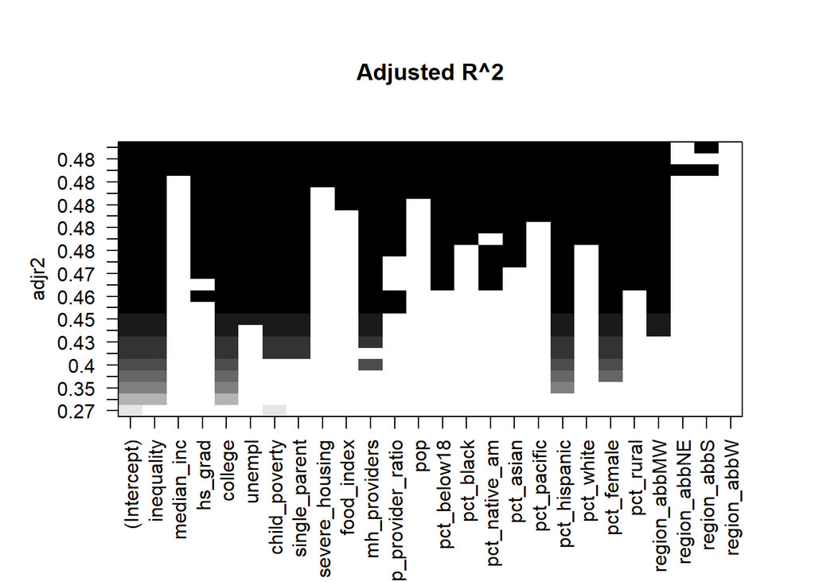

```r
plot(reg.best10, scale = "adjr2", main = "Adjusted R^2")
```

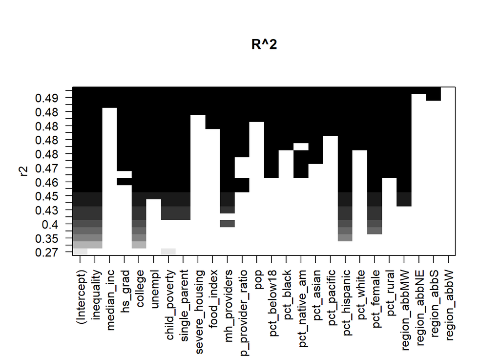

```r
plot(reg.best10, scale = "r2", main = "R^2")
```

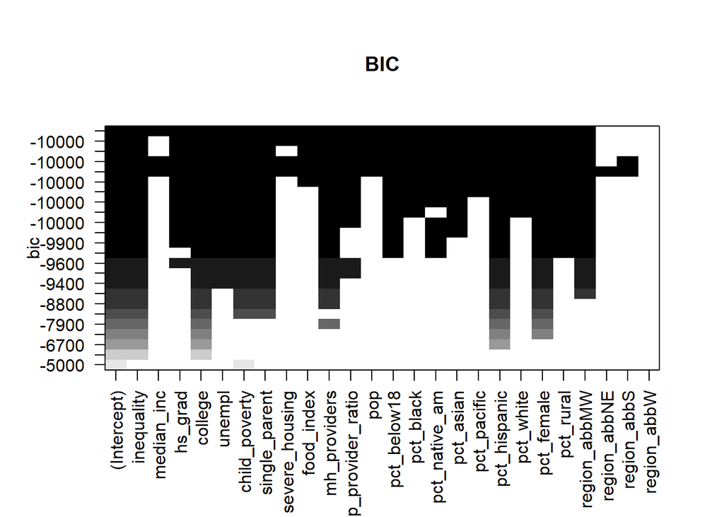

```r
plot(reg.best10, scale = "bic", main = "BIC")
```

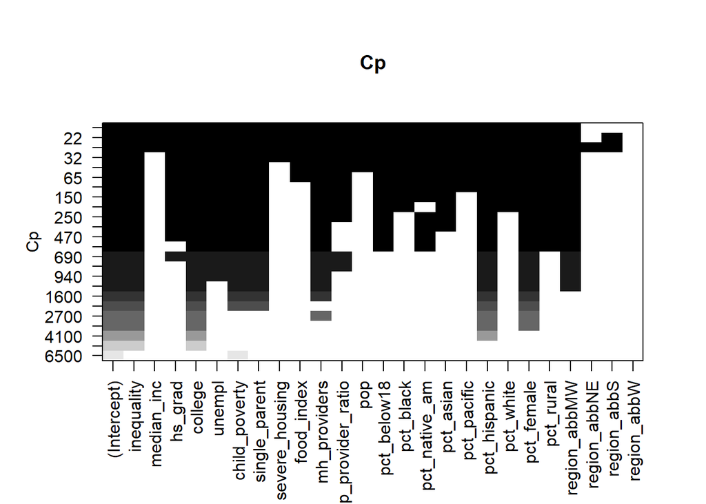

```r
plot(reg.best10, scale = "Cp", main = "Cp")
```

```r
coef(reg.best10, 10, scale = "adjr2") # default BIC
```

```
##        (Intercept)         inequality            college             unempl
##           2.20e+00           1.57e-01          -2.51e+00          -4.49e+00
##      child_poverty      single_parent       mh_providers pop_provider_ratio
##           2.80e+00          -1.55e+00           4.59e+01          -1.95e-05
##       pct_hispanic         pct_female       region_abbMW
##          -1.12e+00           5.68e+00          -1.91e-01
```

```r
summary.out$which[10,]
```

```
   (Intercept)         inequality         median_inc            hs_grad
          TRUE               TRUE              FALSE              FALSE
       college             unempl      child_poverty      single_parent
          TRUE               TRUE               TRUE               TRUE
severe_housing         food_index       mh_providers pop_provider_ratio
         FALSE              FALSE               TRUE               TRUE
           pop        pct_below18          pct_black      pct_native_am
         FALSE              FALSE              FALSE              FALSE
     pct_asian        pct_pacific       pct_hispanic          pct_white
         FALSE              FALSE               TRUE              FALSE
    pct_female          pct_rural       region_abbMW       region_abbNE
          TRUE              FALSE               TRUE              FALSE
   region_abbS        region_abbW
         FALSE              FALSE
```

### 2. Perform Linear Regression with selected variables after feature selection

```r
lm2 <- lm(rankedfs,formula=mental_health_days ~ child_poverty + inequality + unempl + college + mh_providers + pop_provider_ratio + region_abb + single_parent + pct_hispanic + pct_female)
summ(lm2, vifs=T)
```

| Observations | 15728 |
| --- | --- |
| Dependent variable | mental_health_days |
| Type | OLS linear regression |

| F(12,15715) | 1120.94 |
| --- | --- |
| R² | 0.46 |
| Adj. R² | 0.46 |

|  | Est. | S.E. | t val. | p | VIF |
| --- | --- | --- | --- | --- | --- |
| (Intercept) | 2.12 | 0.10 | 20.72 | 0.00 | NA |
| child_poverty | 2.73 | 0.09 | 29.40 | 0.00 | 4.47 |
| inequality | 0.15 | 0.01 | 20.79 | 0.00 | 1.80 |
| unempl | -4.09 | 0.26 | -15.50 | 0.00 | 1.68 |
| college | -2.47 | 0.05 | -45.05 | 0.00 | 2.52 |
| mh_providers | 50.86 | 3.00 | 16.98 | 0.00 | 1.47 |
| pop_provider_ratio | -0.00 | 0.00 | -13.25 | 0.00 | 1.29 |
| region_abbNE | 0.16 | 0.02 | 10.02 | 0.00 | 1.99 |
| region_abbS | 0.22 | 0.01 | 20.70 | 0.00 | 1.99 |
| region_abbW | 0.13 | 0.01 | 9.17 | 0.00 | 1.99 |
| single_parent | -1.57 | 0.06 | -27.81 | 0.00 | 2.11 |
| pct_hispanic | -1.08 | 0.03 | -33.96 | 0.00 | 1.16 |
| pct_female | 5.45 | 0.22 | 25.23 | 0.00 | 1.25 |

Standard errors: OLS

### 3. Plot Output from regsubsets Function in leaps package

```r
library(car)
library(carData)

res.legend <-
    subsets(regsubsets(mental_health_days~. -mental_distress_rate , data = rankedfs, nvmax = 10, nbest = 1, method = "exhaustive"), statistic="adjr2", legend = FALSE, min.size = 5, main = "Adjusted R^2")
```

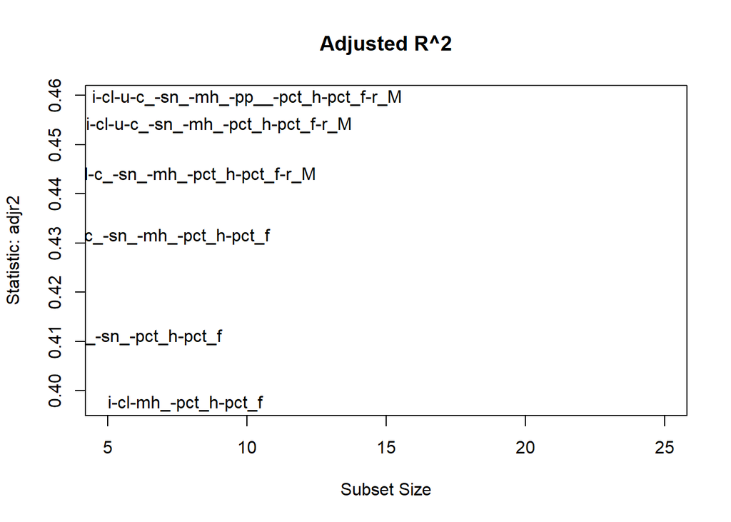

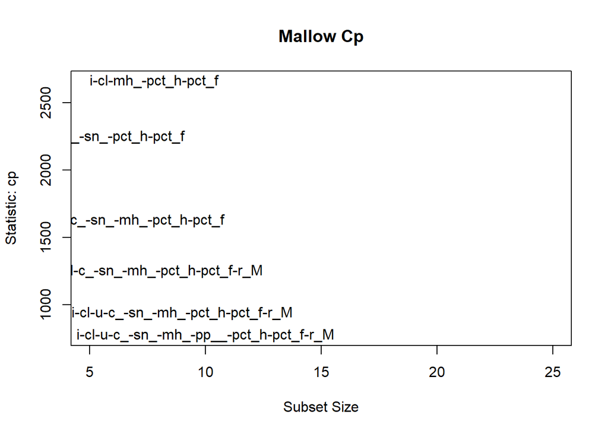

```r
## Mallow Cp
res.legend <-
    subsets(regsubsets(mental_health_days~. -mental_distress_rate , data = rankedfs, nvmax = 10, nbest = 1, method = "exhaustive"), statistic="cp", legend = FALSE, min.size = 5, main = "Mallow Cp")
abline(a = 1, b = 1, lty = 2)
```

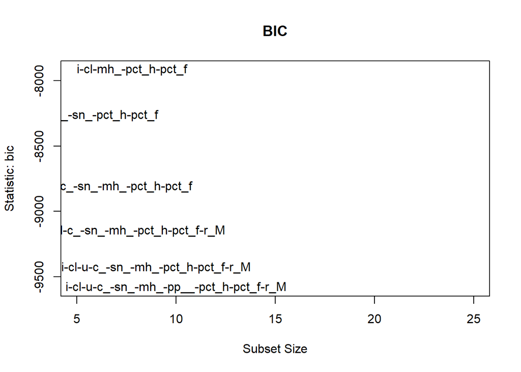

```r
#BIC
res.legend <-
    subsets(regsubsets(mental_health_days~. -mental_distress_rate , data = rankedfs, nvmax = 10, nbest = 1, method = "exhaustive"), statistic="bic", legend = FALSE, min.size = 5, main = "BIC")
abline(a = 1, b = 1, lty = 2)
```

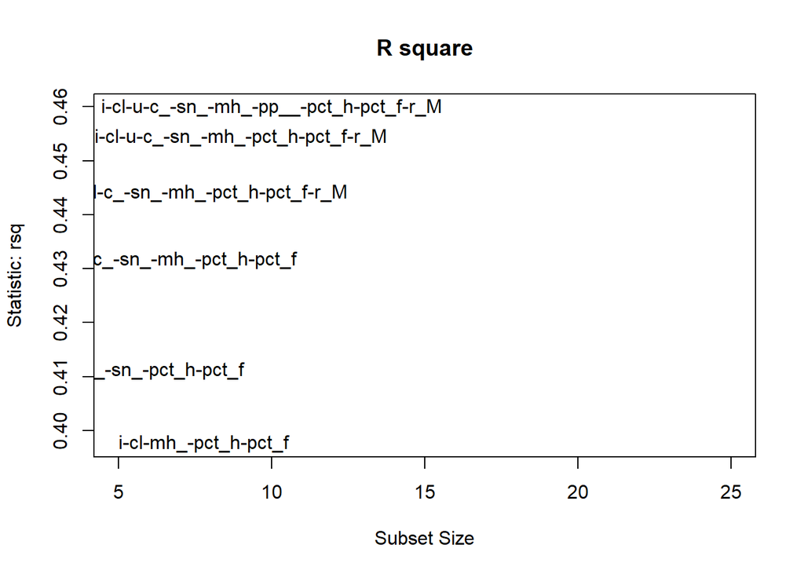

```r
#r2
res.legend <-
    subsets(regsubsets(mental_health_days~. -mental_distress_rate , data = rankedfs, nvmax = 10, nbest = 1, method = "exhaustive"), statistic="rsq", legend = FALSE, min.size = 5, main = "R square")
abline(a = 1, b = 1, lty = 2)
```

```r
res.legend
```

```
##                    Abbreviation
## inequality                    i
## median_inc                  md_
## hs_grad                       h
## college                      cl
## unempl                        u
## child_poverty                c_
## single_parent               sn_
## severe_housing              sv_
## food_index                    f
## mh_providers                mh_
## pop_provider_ratio         pp__
## pop                          pp
## pct_below18                 p_1
## pct_black                 pct_b
## pct_native_am              pc__
## pct_asian                 pct_s
## pct_pacific               pct_p
## pct_hispanic              pct_h
## pct_white                 pct_w
## pct_female                pct_f
## pct_rural                 pct_r
## region_abbMW                r_M
## region_abbNE                r_N
## region_abbS                 r_S
## region_abbW                 r_W
```

```r
# See which model has the highest R Square :
days_maxR2 <- which.max(summary.out$rsq)
days_maxR2
```

The model with 24 variables has the highest R-squared. Variables marked with TRUE are the ones chosen.

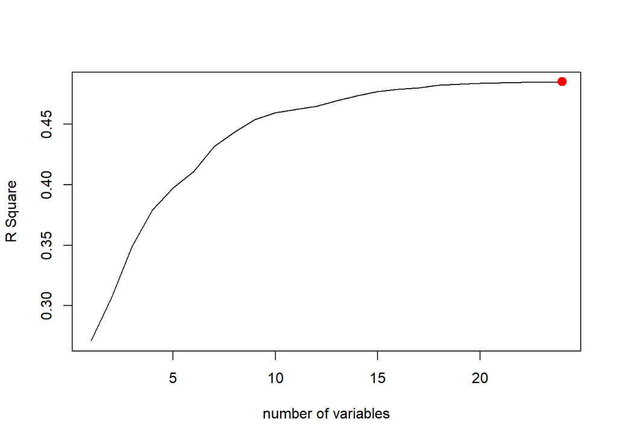

```r
plot(summary.out$adjr2,xlab="number of variables", ylab="R Square", type="l")
points(days_maxR2, summary.out$rsq[days_maxR2], col='red', cex=2, pch=20)
```

```r
# See which model has the highest adjusted R2 :
days_maxAdjR2 <- which.max(summary.out$adjr2)
days_maxAdjR2
```

The model with 23 variables has the highest adjusted $R^2$. Variables marked with TRUE are the ones chosen.

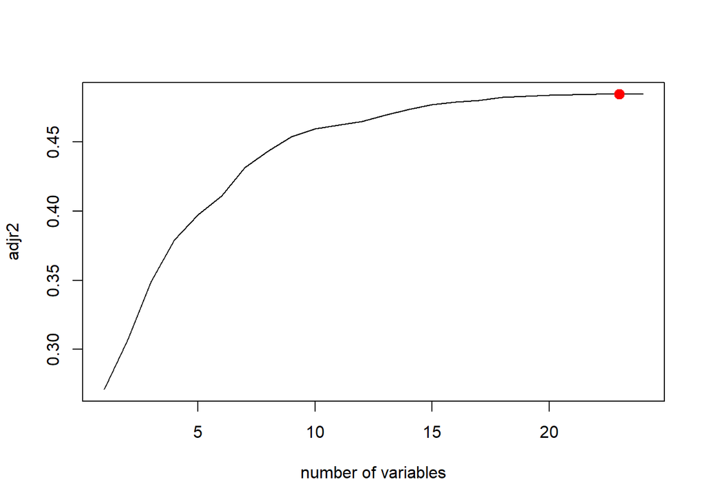

```r
plot(summary.out$adjr2,xlab="number of variables", ylab="adjr2", type="l")
points(days_maxAdjR2, summary.out$adjr2[days_maxAdjR2], col='red', cex=2, pch=20)
```

```r
#See which model has the lowest CP :
days_minCP <- which.min(summary.out$cp)
days_minCP
```

The model with 22 variables has the lowest CP.

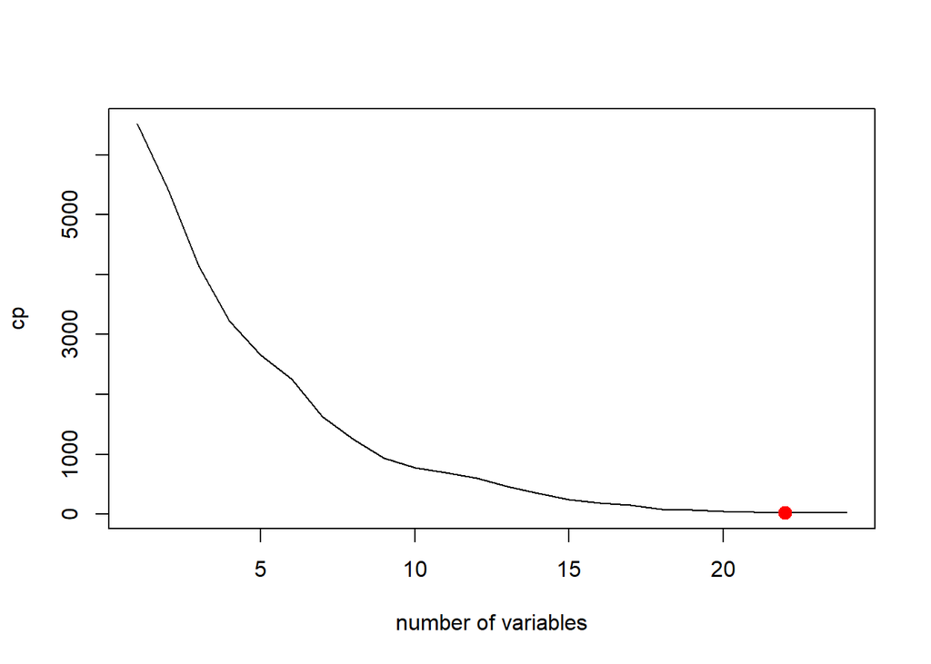

```r
plot(summary.out$cp,xlab="number of variables", ylab="cp", type="l")
points(days_minCP, summary.out$cp[days_minCP], col='red', cex=2, pch=20)
```

```r
#See which model has the lowest BIC :
days_minBIC <- which.min(summary.out$bic)
days_minBIC
```

The model with 22 variables has the lowest BIC.

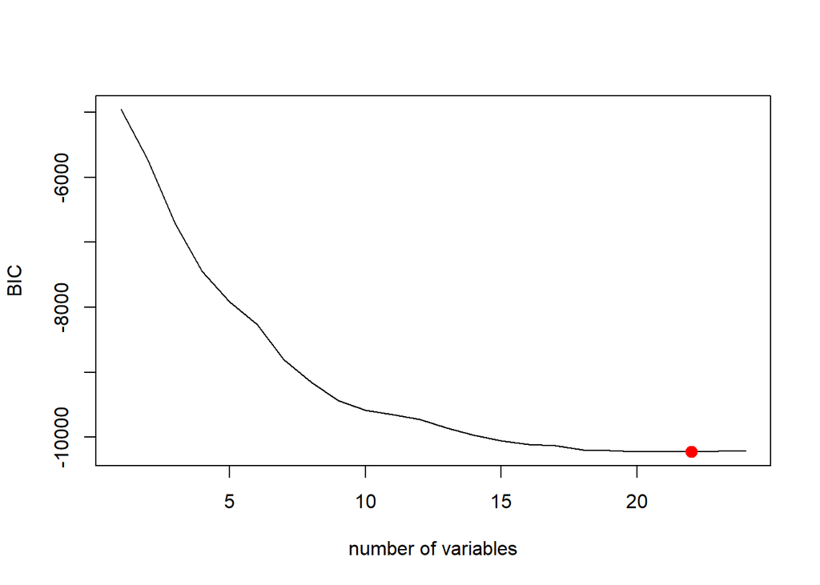

```r
plot(summary.out$bic,xlab="number of variables", ylab="BIC", type="l")
points(days_minBIC, summary.out$bic[days_minBIC], col='red', cex=2, pch=20)
```

```r
#forward and backward selection is same as exhaustive just slight different in forward it start will no variable and iterate till the max variable and backward selection is otherway around.
```

```r
#validation
set.seed(1)
train=sample(c(TRUE, FALSE), nrow(rankedfs), rep=T)
test = (!train)
regfit.best=regsubsets(mental_health_days~.-mental_distress_rate ,data=rankedfs[train,],nvmax = 23)
test.mat = model.matrix(mental_health_days~.-mental_distress_rate , data = rankedfs[test,])
val.errors = rep(NA, 23)
for(i in 1:23){
  coefi = coef(regfit.best, id=i)
   pred = test.mat[,names(coefi)]%*%coefi
   val.errors[i]= mean((rankedfs$mental_health_days[test]-pred)^2)
   }
val.errors
```

```
##  [1] 0.327 0.311 0.292 0.279 0.271 0.265 0.256 0.251 0.246 0.243 0.242 0.241
## [13] 0.238 0.237 0.235 0.234 0.234 0.232 0.232 0.232 0.232 0.231 0.231
```

```r
which.min(val.errors)
```

```
## [1] 22
```

```r
coef(regfit.best,23)
```

```
##        (Intercept)         inequality         median_inc            hs_grad
##           6.52e+00           1.52e-01           2.05e-06           5.91e-01
##            college             unempl      child_poverty      single_parent
##          -2.69e+00          -3.96e+00           2.68e+00          -1.70e+00
##     severe_housing         food_index       mh_providers pop_provider_ratio
##          -3.53e-01          -4.29e-02           3.84e+01          -1.66e-05
##                pop        pct_below18          pct_black      pct_native_am
##           7.13e-08          -2.02e+00          -4.23e+00          -3.33e+00
##          pct_asian        pct_pacific       pct_hispanic          pct_white
##          -6.52e+00          -8.41e+00          -5.08e+00          -4.24e+00
##         pct_female          pct_rural       region_abbMW        region_abbS
##           6.32e+00          -1.90e-01          -1.54e-01           3.00e-02
```

## Target Variable: mental_distress_rate

### 1.Perform Linear Regression with All Predictors

```r
#1.Perform Linear Regression with All Predictors
#Before selecting the best subset of predictors for our regression, let’s run a simple linear regression on our dataset with all predictors to set the base adjusted r² for comparison.

lm3 <- lm(rankedfs,formula=mental_distress_rate ~. -mental_health_days )
summ(lm3)
```

| Observations | 15728 |
| --- | --- |
| Dependent variable | mental_distress_rate |
| Type | OLS linear regression |

| F(24,15703) | 714.42 |
| --- | --- |
| R² | 0.52 |
| Adj. R² | 0.52 |

|  | Est. | S.E. | t val. | p |
| --- | --- | --- | --- | --- |
| (Intercept) | 0.21 | 0.02 | 14.06 | 0.00 |
| inequality | 0.01 | 0.00 | 22.69 | 0.00 |
| median_inc | 0.00 | 0.00 | 2.84 | 0.00 |
| hs_grad | 0.02 | 0.00 | 10.56 | 0.00 |
| college | -0.09 | 0.00 | -43.94 | 0.00 |
| unempl | -0.21 | 0.01 | -23.33 | 0.00 |
| child_poverty | 0.11 | 0.00 | 28.67 | 0.00 |
| single_parent | -0.07 | 0.00 | -31.66 | 0.00 |
| severe_housing | -0.01 | 0.00 | -1.63 | 0.10 |
| food_index | -0.00 | 0.00 | -8.23 | 0.00 |
| mh_providers | 1.11 | 0.10 | 10.75 | 0.00 |
| pop_provider_ratio | -0.00 | 0.00 | -10.57 | 0.00 |
| pop | 0.00 | 0.00 | 2.64 | 0.01 |
| pct_below18 | -0.06 | 0.01 | -12.08 | 0.00 |
| pct_black | -0.14 | 0.01 | -9.14 | 0.00 |
| pct_native_am | -0.10 | 0.02 | -6.31 | 0.00 |
| pct_asian | -0.23 | 0.02 | -13.69 | 0.00 |
| pct_pacific | -0.25 | 0.05 | -5.04 | 0.00 |
| pct_hispanic | -0.17 | 0.01 | -11.64 | 0.00 |
| pct_white | -0.15 | 0.01 | -10.12 | 0.00 |
| pct_female | 0.21 | 0.01 | 27.50 | 0.00 |
| pct_rural | -0.00 | 0.00 | -6.72 | 0.00 |
| region_abbNE | 0.00 | 0.00 | 3.02 | 0.00 |
| region_abbS | 0.00 | 0.00 | 8.47 | 0.00 |
| region_abbW | 0.00 | 0.00 | 5.03 | 0.00 |

Standard errors: OLS

```r
# feature selection(mental distress rate)
library(leaps)
reg2.best10 <- regsubsets(mental_distress_rate~. -mental_health_days, data = rankedfs, nvmax = NULL, nbest = 1, method = "exhaustive")

reg2.best10
```

```r
summary2.out <- summary(reg2.best10)
as.data.frame(summary2.out$outmat)
```

```
##           inequality median_inc hs_grad college unempl child_poverty
## 1  ( 1 )                                                           *
## 2  ( 1 )                                      *                    *
## 3  ( 1 )           *                          *
## 4  ( 1 )           *                          *
## 5  ( 1 )           *                          *                    *
## 6  ( 1 )           *                          *                    *
## 7  ( 1 )           *                          *      *             *
## 8  ( 1 )           *                          *      *             *
## 9  ( 1 )           *                          *      *             *
## 10  ( 1 )          *                          *      *             *
## 11  ( 1 )          *                          *      *             *
## 12  ( 1 )          *                          *      *             *
## 13  ( 1 )          *                          *      *             *
## 14  ( 1 )          *                          *      *             *
```

[output cut: 110 more lines]

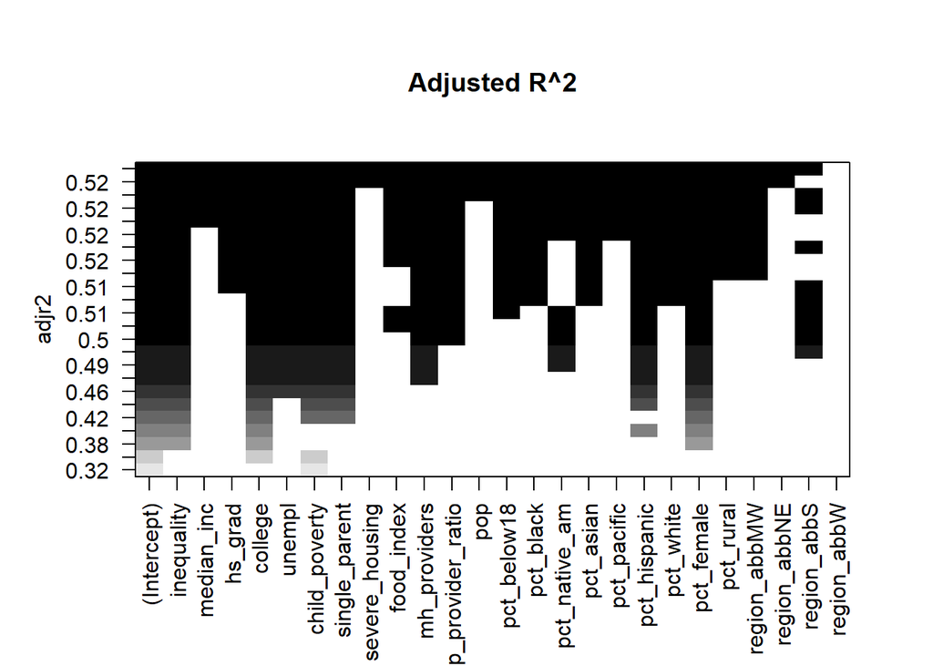

```r
plot(reg2.best10, scale = "adjr2", main = "Adjusted R^2")
```

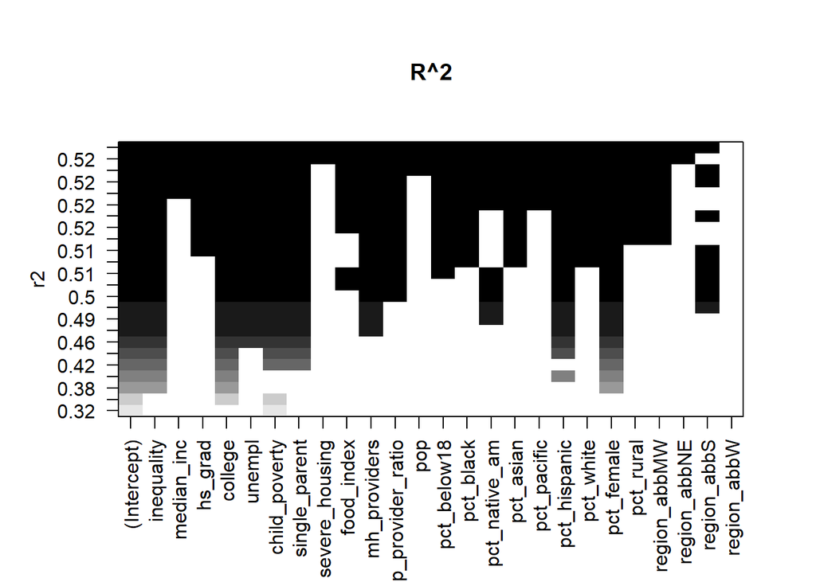

```r
plot(reg2.best10, scale = "r2", main = "R^2")
```

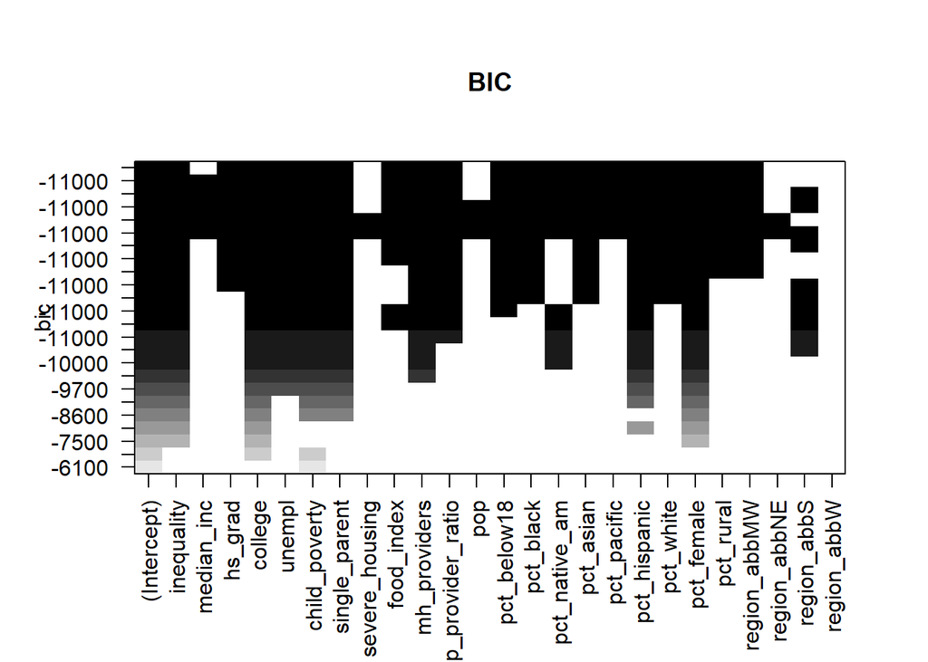

```r
plot(reg2.best10, scale = "bic", main = "BIC")
```

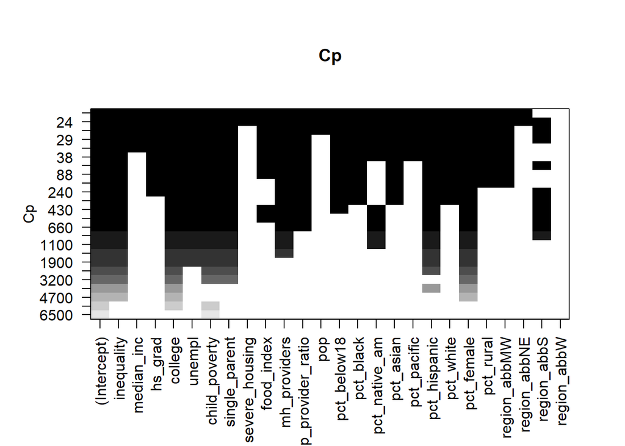

```r
plot(reg2.best10, scale = "Cp", main = "Cp")
```

```r
coef(reg2.best10, 10, scale = "adjr2") # default BIC
```

```
##   (Intercept)    inequality       college        unempl child_poverty
##       0.05396       0.00597      -0.07621      -0.20307       0.11434
## single_parent  mh_providers pct_native_am  pct_hispanic    pct_female
##      -0.05768       1.86752       0.04196      -0.02817       0.17954
##   region_abbS
##       0.00491
```

```r
summary2.out$which[10,]
```

```
   (Intercept)         inequality         median_inc            hs_grad
          TRUE               TRUE              FALSE              FALSE
       college             unempl      child_poverty      single_parent
          TRUE               TRUE               TRUE               TRUE
severe_housing         food_index       mh_providers pop_provider_ratio
         FALSE              FALSE               TRUE              FALSE
           pop        pct_below18          pct_black      pct_native_am
         FALSE              FALSE              FALSE               TRUE
     pct_asian        pct_pacific       pct_hispanic          pct_white
         FALSE              FALSE               TRUE              FALSE
    pct_female          pct_rural       region_abbMW       region_abbNE
          TRUE              FALSE              FALSE              FALSE
   region_abbS        region_abbW
          TRUE              FALSE
```

### 2.Perform Linear Regression with selected variables after feature selection

```r
lm4 <- lm(rankedfs,formula=mental_distress_rate ~  inequality + college + mh_providers + pct_female + child_poverty  + unempl + single_parent + region_abb + pct_hispanic + pct_native_am)
summ(lm4)
```

| Observations | 15728 |
| --- | --- |
| Dependent variable | mental_distress_rate |
| Type | OLS linear regression |

| F(12,15715) | 1296.98 |
| --- | --- |
| R² | 0.50 |
| Adj. R² | 0.50 |

|  | Est. | S.E. | t val. | p |
| --- | --- | --- | --- | --- |
| (Intercept) | 0.05 | 0.00 | 15.75 | 0.00 |
| inequality | 0.01 | 0.00 | 24.10 | 0.00 |
| college | -0.08 | 0.00 | -41.58 | 0.00 |
| mh_providers | 1.74 | 0.10 | 18.27 | 0.00 |
| pct_female | 0.18 | 0.01 | 24.99 | 0.00 |
| child_poverty | 0.12 | 0.00 | 37.54 | 0.00 |
| unempl | -0.21 | 0.01 | -23.80 | 0.00 |
| single_parent | -0.06 | 0.00 | -30.43 | 0.00 |
| region_abbNE | 0.00 | 0.00 | 3.77 | 0.00 |
| region_abbS | 0.01 | 0.00 | 16.10 | 0.00 |
| region_abbW | 0.00 | 0.00 | 4.04 | 0.00 |
| pct_hispanic | -0.03 | 0.00 | -27.70 | 0.00 |
| pct_native_am | 0.04 | 0.00 | 19.28 | 0.00 |

Standard errors: OLS

### 3. Plot Output from regsubsets Function in leaps package

```r
library(car)
library(carData)
res.legend <-
    subsets(regsubsets(mental_distress_rate~. -mental_health_days, data = rankedfs, nvmax = 10, nbest = 1, method = "exhaustive"), statistic="adjr2", legend = FALSE, min.size = 5, main = "Adjusted R^2")
```

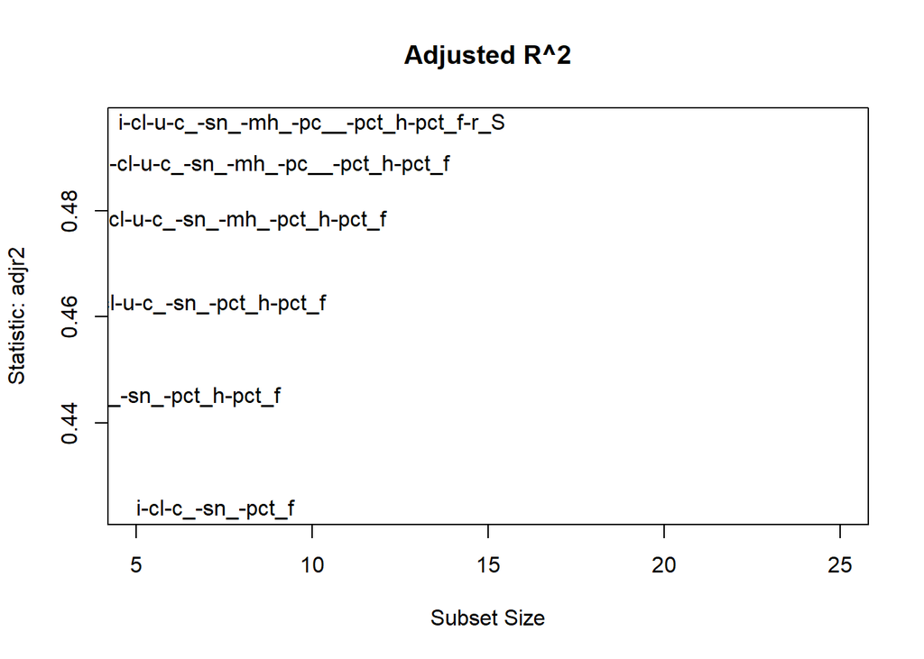

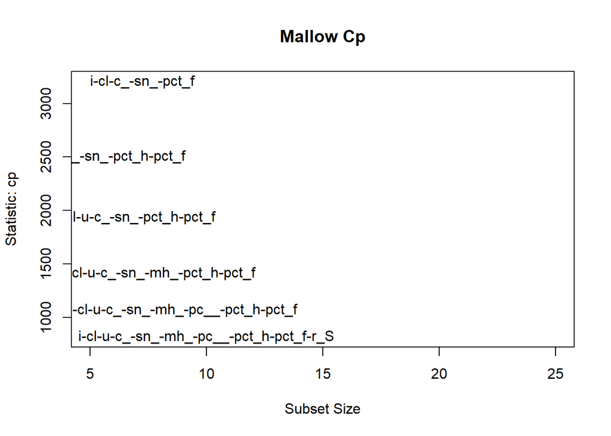

```r
## Mallow Cp
res.legend <-
    subsets(regsubsets(mental_distress_rate~. -mental_health_days, data = rankedfs, nvmax = 10, nbest = 1, method = "exhaustive"), statistic="cp", legend = FALSE, min.size = 5, main = "Mallow Cp")
abline(a = 1, b = 1, lty = 2)
```

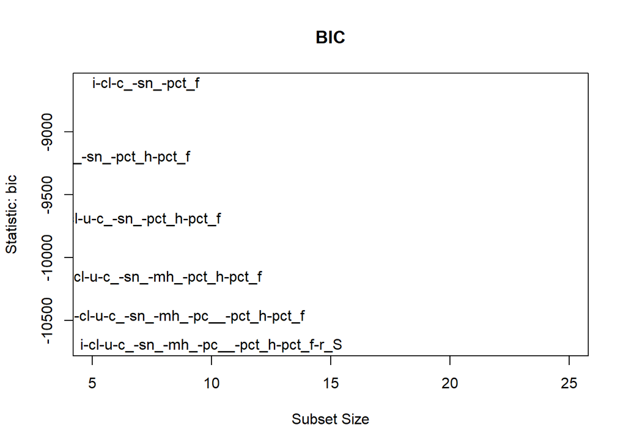

```r
#BIC
res.legend <-
    subsets(regsubsets(mental_distress_rate~. -mental_health_days, data = rankedfs, nvmax = 10, nbest = 1, method = "exhaustive"), statistic="bic", legend = FALSE, min.size = 5, main = "BIC")
abline(a = 1, b = 1, lty = 2)
```

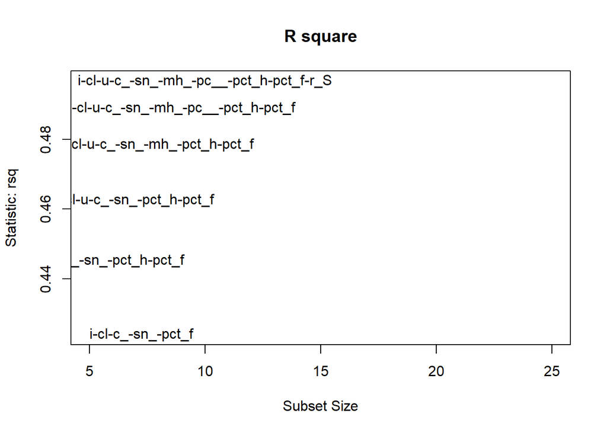

```r
#r2
res.legend <-
    subsets(regsubsets(mental_distress_rate~. -mental_health_days, data = rankedfs, nvmax = 10, nbest = 1, method = "exhaustive"), statistic="rsq", legend = FALSE, min.size = 5, main = "R square")
abline(a = 1, b = 1, lty = 2)
```

```r
res.legend
```

```
##                    Abbreviation
## inequality                    i
## median_inc                  md_
## hs_grad                       h
## college                      cl
## unempl                        u
## child_poverty                c_
## single_parent               sn_
## severe_housing              sv_
## food_index                    f
## mh_providers                mh_
## pop_provider_ratio         pp__
## pop                          pp
## pct_below18                 p_1
## pct_black                 pct_b
## pct_native_am              pc__
## pct_asian                 pct_s
## pct_pacific               pct_p
## pct_hispanic              pct_h
## pct_white                 pct_w
## pct_female                pct_f
## pct_rural                 pct_r
## region_abbMW                r_M
## region_abbNE                r_N
## region_abbS                 r_S
## region_abbW                 r_W
```

```r
#See which model has the highest R Square :
rate_maxR2 <- which.max(summary2.out$rsq)
rate_maxR2
```

The model with 24 variables has the highest R-squared. Variables marked with TRUE are the ones chosen.

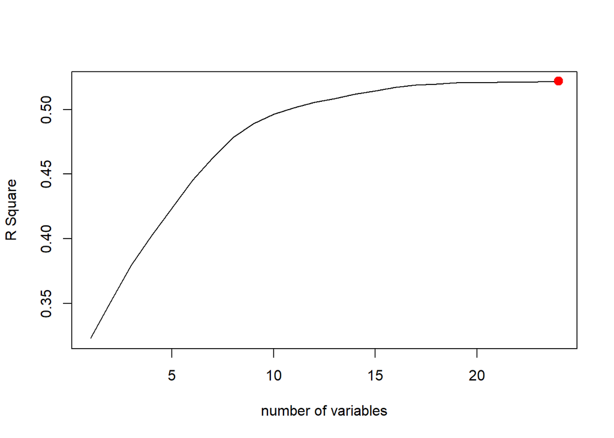

```r
plot(summary2.out$adjr2,xlab="number of variables", ylab="R Square", type="l")
points(rate_maxR2, summary2.out$rsq[rate_maxR2], col='red', cex=2, pch=20)
```

```r
#See which model has the highest adjusted R2 :
rate_maxAdjR2 <- which.max(summary2.out$adjr2)
rate_maxAdjR2
```

The model with 24 variables has the highest adjusted $R^2$. Variables marked with TRUE are the ones chosen.

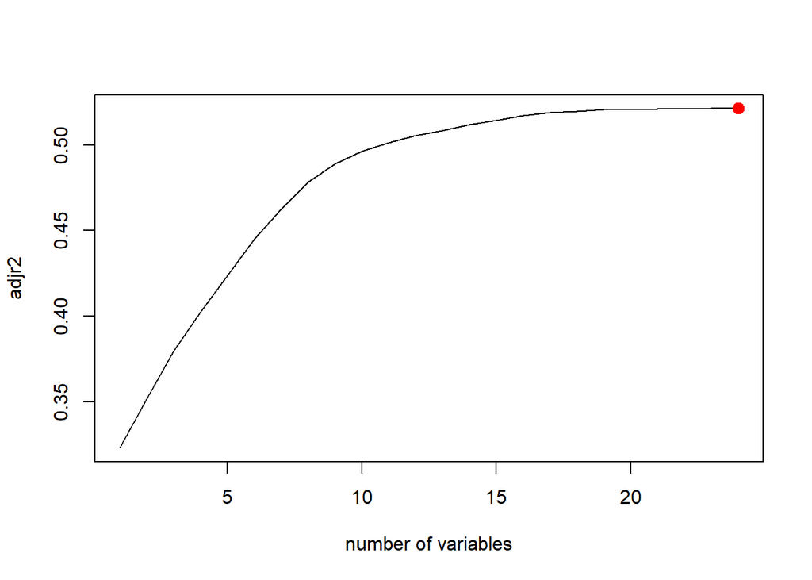

```r
plot(summary2.out$adjr2,xlab="number of variables", ylab="adjr2", type="l")
points(rate_maxAdjR2, summary2.out$adjr2[rate_maxAdjR2], col='red', cex=2, pch=20)
```

```r
#See which model has the lowest CP :
rate_minCP <- which.min(summary2.out$cp)
rate_minCP
```

The model with 23 variables has the lowest CP.

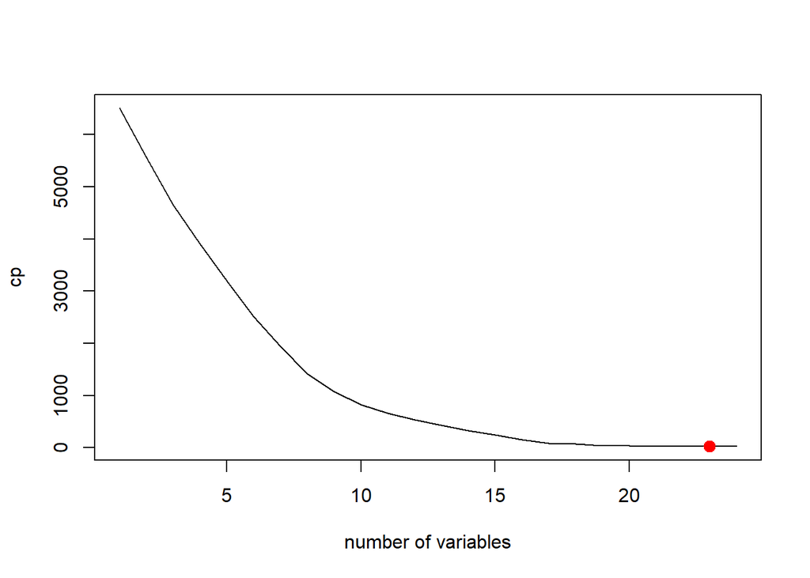

```r
plot(summary2.out$cp,xlab="number of variables", ylab="cp", type="l")
points(rate_minCP, summary2.out$cp[rate_minCP], col='red', cex=2, pch=20)
```

```r
#See which model has the lowest BIC :
rate_minBIC <- which.min(summary2.out$bic)
rate_minBIC
```

```
## [1] 19
```

The model with 19 variables has the lowest BIC.

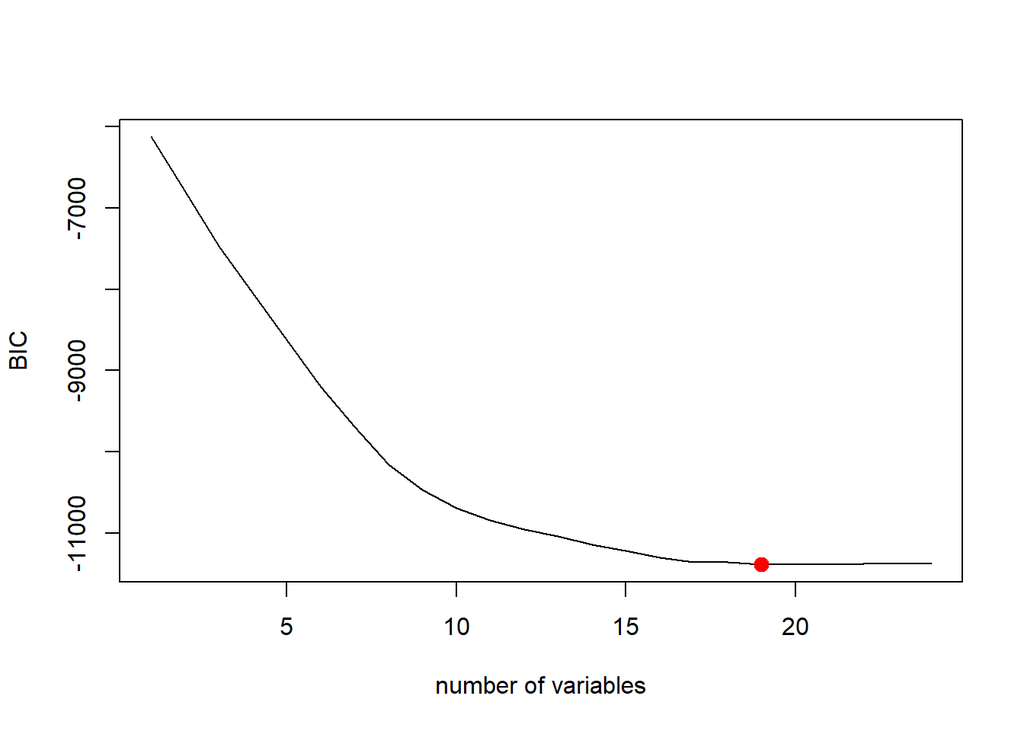

```r
plot(summary2.out$bic,xlab="number of variables", ylab="BIC", type="l")
points(rate_minBIC, summary2.out$bic[rate_minBIC], col='red', cex=2, pch=20)
```

```r
#forward and backward selection is same as exhaustive just slight different in forward it start will no variable and iterate till the max variable and backward selection is otherway around.
```

```r
#validation
set.seed(1)
train=sample(c(TRUE, FALSE), nrow(rankedfs), rep=T)
test = (!train)
regfit.best=regsubsets(mental_distress_rate~.-mental_health_days,data=rankedfs[train,],nvmax = 23)
test.mat = model.matrix(mental_distress_rate~.-mental_health_days, data = rankedfs[test,])
val.errors = rep(NA, 23)
for(i in 1:23){
  coefi = coef(regfit.best, id=i)
   pred = test.mat[,names(coefi)]%*%coefi
   val.errors[i]= mean((rankedfs$mental_health_days[test]-pred)^2)
   }
val.errors
```

```
##  [1] 16.1 16.1 16.1 16.1 16.1 16.1 16.1 16.1 16.1 16.1 16.1 16.1 16.1 16.1 16.1
## [16] 16.1 16.1 16.1 16.1 16.1 16.1 16.1 16.1
```

```r
which.min(val.errors)
```

```
## [1] 13
```

```r
coef(regfit.best,23)
```

```
##        (Intercept)         inequality         median_inc            hs_grad
##           1.86e-01           5.57e-03           4.96e-08           2.15e-02
##            college             unempl      child_poverty      single_parent
##          -8.58e-02          -1.94e-01           1.04e-01          -7.10e-02
##         food_index       mh_providers pop_provider_ratio                pop
##          -1.93e-03           1.14e+00          -5.79e-07           1.13e-09
##        pct_below18          pct_black      pct_native_am          pct_asian
##          -6.20e-02          -1.06e-01          -6.75e-02          -1.97e-01
##        pct_pacific       pct_hispanic          pct_white         pct_female
##          -2.04e-01          -1.39e-01          -1.21e-01           2.06e-01
##          pct_rural       region_abbMW       region_abbNE        region_abbS
##          -3.46e-03          -2.69e-03          -1.19e-03           9.11e-04
```

## ANOVA Comparison of Models

```r
anovaRes_mental_health_days <- anova(lm1,lm2)
anovaRes_mental_distress_rate <- anova(lm3,lm4)

xkabledply(anovaRes_mental_health_days, title = "ANOVA comparison between two linear models for mental health days : lm1 and lm2")
```

ANOVA comparison between two linear models for mental health days : lm1 and lm2

| Res.Df | RSS | Df | Sum of Sq | F | Pr(>F) |
| --- | --- | --- | --- | --- | --- |
| 15703 | 3608 | NA | NA | NA | NA |
| 15715 | 3777 | -12 | -169 | 61.4 | 0 |

```r
xkabledply(anovaRes_mental_distress_rate, title = "ANOVA comparison between two linear models for mental distress rate : lm3 and lm4")
```

ANOVA comparison between two linear models for mental distress rate : lm3 and lm4

| Res.Df | RSS | Df | Sum of Sq | F | Pr(>F) |
| --- | --- | --- | --- | --- | --- |
| 15703 | 3.99 | NA | NA | NA | NA |
| 15715 | 4.20 | -12 | -0.204 | 66.7 | 0 |

# Regression Tree Models

## Regression Tree - mental_health_days

In addition to the linear models above, regression tree models were also experimented with to determine if other model types could improve predicting the prevalence of the mental health variables and variable importance for predicting each mental health variable.

The regression tree model analyzes the relationship between number of poor mental health days versus all the economic inequality variables included in our dataset. Additionally, a region was included as an explanatory variable to observe the impact that a specific region has on the dependent variable. In other words, the model regresses mental_health_days against inequality, median_inc, hs_grad, college, unempl, child_poverty, single_parent, severe_housing, food_index, mh_providers, pop_provider_ratio, region, and year.

The initial regression tree model below has a max depth of 8 and a complexity penalty (cp), or complexity parameter, of 0.004. This is to allow for a large regression tree in order to produce a model that can best fit the data. However, it must be acknowledge that a larger tree will run the risk of over fitting the data making the model worse at predicting the target variable (i.e. the dependent variable).

The following regression tree has 17 leaf nodes.

The summary table of the regression tree indicates the order of variable importance for each variable within the regression. Interestingly, the top three most important variables in order of importance is year, child_pov, and median_inc.

```r
#Regression Tree - Number of Mentally Unhealthy Days

#View(ranked)
#str(ranked)

#Remove NA values.
ranked <- na.omit(ranked)

#Creating Train and Test Set - ranked
set.seed(123)
train = sample(1:nrow(ranked), nrow(ranked)/1.25)

#First Model for Number of Mentally Unhealthy Days (ranked; all vars.)
model_ment_helth_day_tree <- rpart(mental_health_days ~ inequality + median_inc + hs_grad + college + unempl + child_poverty + single_parent + severe_housing + food_index + mh_providers + pop_provider_ratio + region + year, ranked, subset=train, control = list(maxdepth=8, cp=0.004))

#Summary for Number of Mentally Unhealthy Days
summ_table1=summary(model_ment_helth_day_tree)
table1_FI_tree<-data.frame(summ_table1$variable.importance)
```

```r
table1_FI_tree %>%
  kbl(caption="Variable Importance: Target Y - mental_health_days (all vars.) ",
       format= "html", col.names = c("Feature Importance"),
      align="r") %>%
   kable_classic_2(full_width = F, html_font = "helvetica")
```

Variable Importance: Target Y - mental_health_days (all vars.)

|  | Feature Importance |
| --- | --- |
| year | 1586.83 |
| child_poverty | 1502.05 |
| median_inc | 1173.68 |
| food_index | 615.87 |
| unempl | 588.94 |
| college | 583.42 |
| single_parent | 545.39 |
| inequality | 54.16 |
| region | 52.43 |
| mh_providers | 14.08 |
| hs_grad | 13.31 |
| pop_provider_ratio | 12.39 |
| severe_housing | 7.11 |

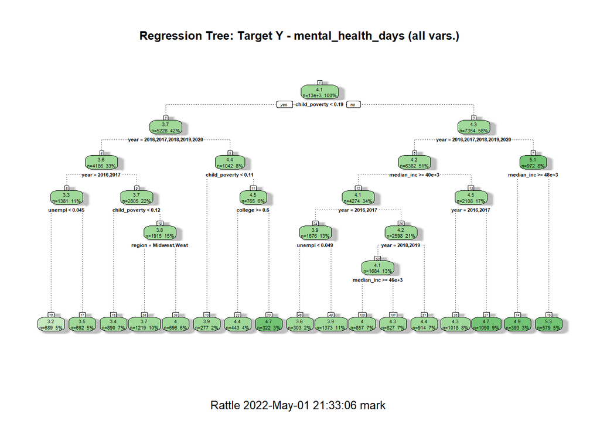

```r
#Plot Regression Tree
#rpart.plot(model_ment_helth_day_tree)
fancyRpartPlot(model_ment_helth_day_tree, main = "Regression Tree: Target Y - mental_health_days (all vars.)")
```

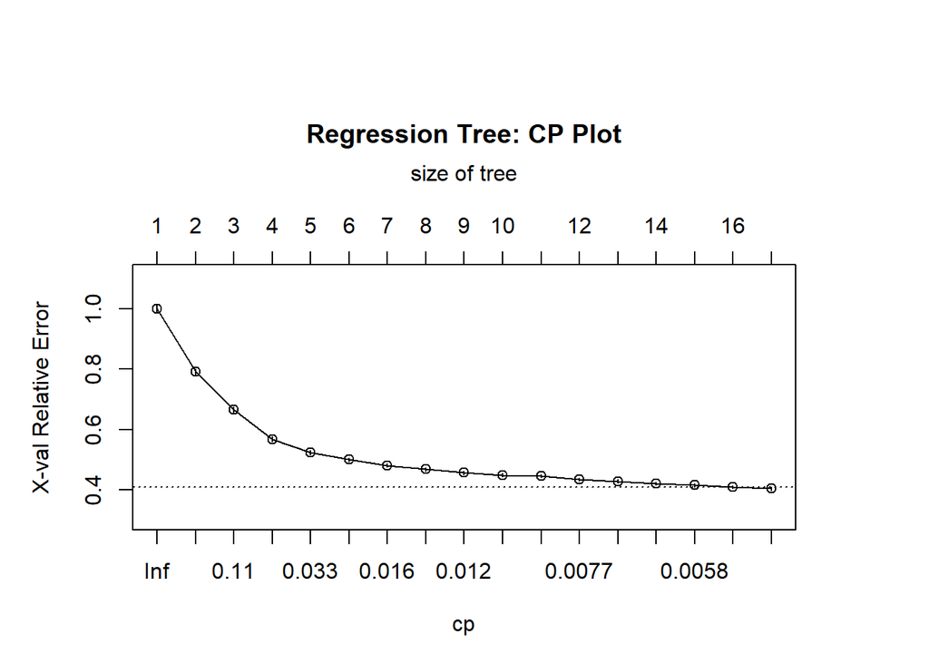

```r
#Print Complexity Penalty
#printcp(model_ment_helth_day_tree)

#Plotting Complexity Parameters
par(mar = c(5, 5, 10, 5))
plotcp(model_ment_helth_day_tree, minline = TRUE, lty = 3, col = 1, main="Regression Tree: CP Plot")
```

```r
#R-squared
#rsq.rpart(model_ment_helth_day_tree)
```